# Analysing Sentences Backbone Communities

#### Top terms 12_148: equilibria, equilibrium, equilibrium_beliefs, personal_equilibrium, equilibrium_selection (2010-2019)

| Sentence | Title | Year | Journal | Authors | Distance to Centroid |
| --- | --- | --- | --- | --- | --- |
| Together, Remarks 1 and 2 suggest two important implications of the equilibrium. | [REDISTRIBUTION, PORK, AND ELECTIONS](http://www.jstor.org/stable/24538787) | 2013 | Journal of the European Economic Association | John D. Huber , Michael M. Ting | 6.941577 |
| This result speaks to the equilibrium effects at play. | [Student Portfolios and the College Admissions Problem](http://www.jstor.org/stable/43551617) | 2014 | The Review of Economic Studies | HECTOR CHADE , GREGORY LEWIS, LONES SMITH | 7.103060 |
| While there may exist equilibrium sequences satisfying FIE even when SPM is violated, the beliefs and strategies in such equilibria are very sensitive to the voting rule. | [PREFERENCE MONOTONICITY AND INFORMATION AGGREGATION IN ELECTIONS](http://www.jstor.org/stable/23524175) | 2013 | Econometrica | Sourav Bhattacharya | 7.120855 |
| Setup Because we define a new equilibrium concept, we present it in a general setting. | [Competitive Equilibrium in Markets for Votes](http://www.jstor.org/stable/10.1086/667988) | 2012 | Journal of Political Economy | Alessandra Casella , Aniol Llorente-Saguer, Thomas R. Palfrey | 7.125314 |
| We now argue that there exists an equilibrium implementing /. | [MECHANISM DESIGN WITH AMBIGUOUS COMMUNICATION DEVICES](http://www.jstor.org/stable/24029295) | 2014 | Econometrica | Subir Bose , Ludovic Renou | 7.137970 |

#### Top terms 12_152: beliefs, equilibrium_beliefs, heterogeneous_beliefs, agents_beliefs, rational_beliefs (2010-2019)

| Sentence | Title | Year | Journal | Authors | Distance to Centroid |
| --- | --- | --- | --- | --- | --- |
| As beliefs play an important role in our argument, we do not want our argument to depend on arbitrary out-of equilibrium beliefs; we therefore impose a strong refinement, namely that they satisfy the … | [COMPETITION, DISCLOSURE AND SIGNALLING](http://www.jstor.org/stable/24736900) | 2015 | The Economic Journal | Maarten C. W. Janssen, Santanu Roy | 6.367434 |
| Note also that the equilibrium restrictions on beliefs appear to contradict some of our previous results. | [MEASURING THE WILLINGNESS TO PAY TO AVOID GUILT: ESTIMATION USING EQUILIBRIUM AND STATED BELIEF MODELS](http://www.jstor.org/stable/23017555) | 2011 | Journal of Applied Econometrics | CHARLES BELLEMARE, ALEXANDER SEBALD , MARTIN STROBEL | 6.786760 |
| C. The Role of Beliefs We comment briefly on the role of off-the-equilibrium path beliefs in the definition of an equilibrium. | [Markets with Multidimensional Private Information](http://www.jstor.org/stable/26528485) | 2018 | American Economic Journal: Microeconomics | Veronica Guerrieri, Robert Shimer | 6.933570 |
| Testing the Belief Specification Against the Data C. Internal Rationality and Discounted Sums It appears to be a commonly held view among academic economists that rational behavior leaves no room for … | [House Price Booms and the Current Account](http://www.jstor.org/stable/10.1086/663990) | 2012 | NBER Macroeconomics Annual | Klaus Adam , Pei Kuang , Albert Marcet | 7.021659 |
| The objective of this paper is the empirical test of Theorem 3 stated below and for that we use only the most basic restrictions the theory of Rational Beliefs imposes. | [Diverse beliefs and time variability of risk premia](http://www.jstor.org/stable/41485841) | 2011 | Economic Theory | Mordecai Kurz , Maurizio Motolese | 7.069157 |

### Top articles (most sentences) of the backbone cluster

| Title | Year | Journal | Authors | Number sentences | Words Similarity |
| --- | --- | --- | --- | --- | --- |
| [Belief heterogeneity and survival in incomplete markets](http://www.jstor.org/stable/41408700) | 2012 | Economic Theory | Tarek Coury , Emanuela Sciubba | 24 | 0.620 |
| [A WELFARE CRITERION FOR MODELS WITH DISTORTED BELIEFS](http://www.jstor.org/stable/26372586) | 2014 | The Quarterly Journal of Economics | Markus K. Brunnermeier, Alp Simsek , Wei Xiong | 24 | 0.624 |
| [RULE RATIONALITY](http://www.jstor.org/stable/44075376) | 2016 | International Economic Review | Yuval Heller, Eyal Winter | 22 | 0.618 |
| [Symposium: on the role of market belief in economic dynamics, an introduction](http://www.jstor.org/stable/41485838) | 2011 | Economic Theory | Mordecai Kurz | 20 | 0.633 |
| [Diverse beliefs and time variability of risk premia](http://www.jstor.org/stable/41485841) | 2011 | Economic Theory | Mordecai Kurz , Maurizio Motolese | 18 | 0.649 |
| [DYNAMIC COORDINATION AND THE OPTIMAL STIMULUS POLICIES](http://www.jstor.org/stable/45023150) | 2018 | The Economic Journal | Bernardo Guimaraes, Caio Machado | 18 | 0.621 |
| [Rational overconfidence and social security: subjective beliefs, objective welfare](http://www.jstor.org/stable/26705023) | 2018 | Economic Theory | Carsten Krabbe Nielsen | 18 | 0.678 |
| [Rational Belief Structures and Rational Belief Equilibria](http://www.jstor.org/stable/25054981) | 1996 | Economic Theory | Carsten Krabbe Nielsen | 17 | 0.677 |
| [Signalling and Entry Deterrence: A Multidimensional Analysis](http://www.jstor.org/stable/25046330) | 2007 | The RAND Journal of Economics | Kyle Bagwell | 16 | 0.611 |
| [On Relational Structures and Non-Equilibrium in Economic Theory](http://www.jstor.org/stable/40325004) | 1985 | Eastern Economic Journal | Douglas Vickers | 14 | 0.614 |
| [On Rational Belief Equilibria](http://www.jstor.org/stable/25054812) | 1994 | Economic Theory | Mordecai Kurz | 14 | 0.695 |
| [Should Economists Dispense with the Notion of Equilibrium?](http://www.jstor.org/stable/4538566) | 1997 | Journal of Post Keynesian Economics | Mark Setterfield | 14 | 0.613 |
| [Utility from anticipation and personal equilibrium](http://www.jstor.org/stable/40784505) | 2010 | Economic Theory | Botond Kőszegi | 14 | 0.601 |
| [Price stabilizing, Pareto improving policies](http://www.jstor.org/stable/41485846) | 2011 | Economic Theory | Carsten Krabbe Nielsen | 14 | 0.673 |
| [IRRATIONALITY-PROOFNESS: MARKETS VERSUS GAMES](http://www.jstor.org/stable/24517051) | 2014 | International Economic Review | Michael Mandler | 14 | 0.644 |

### Top articles (most sentences) of the cluster for each time window

#### Top articles for 12_86: equilibrium, conjectural_equilibrium, disequilibrium, market_equilibrium, equilibrium_theory (1970-1979)

| Title | Year | Journal | Authors | Number sentences | Words Similarity |
| --- | --- | --- | --- | --- | --- |
| [On Non-Walrasian Equilibria](http://www.jstor.org/stable/2297079) | 1978 | The Review of Economic Studies | Frank Hahn | 10 | 0.617 |
| [The Microfoundations of Macroeconomics: A Critical Survey](http://www.jstor.org/stable/2722711) | 1977 | Journal of Economic Literature | E. Roy Weintraub | 7 | 0.608 |
| [Informational Equilibrium](http://www.jstor.org/stable/1914187) | 1979 | Econometrica | John G. Riley | 7 | 0.590 |
| [Temporary General Equilibrium Theory](http://www.jstor.org/stable/1911674) | 1977 | Econometrica | Jean Michel Grandmont | 6 | 0.608 |
| [Hypothesis and Paradigm in the Theory of the Firm](http://www.jstor.org/stable/2230322) | 1971 | The Economic Journal | Brian J. Loasby | 5 | 0.603 |
| [Economic Methodology in the Face of Uncertainty: The Modelling Methods of Keynes and the Post-Keynesians](http://www.jstor.org/stable/2230743) | 1976 | The Economic Journal | J. A. Kregel | 5 | 0.596 |
| [The Non-Existence of Informational Equilibria](http://www.jstor.org/stable/2296901) | 1977 | The Review of Economic Studies | Jerry Green | 5 | 0.599 |
| [A General Equilibrium Entrepreneurial Theory of Firm Formation Based on Risk Aversion](http://www.jstor.org/stable/1831005) | 1979 | Journal of Political Economy | Richard E. Kihlstrom, Jean-Jacques Laffont | 5 | 0.593 |
| [The Rigidity of Wages and the Persistence of Unemployment](http://www.jstor.org/stable/2534105) | 1975 | Brookings Papers on Economic Activity | Robert E. Hall , Christopher Sims, Robert Solow , R. A. Gordon | 4 | 0.624 |
| [The Cambridge Controversies: Old Ways and New Horizons–Or Dead End?](http://www.jstor.org/stable/2662910) | 1976 | Oxford Economic Papers | G. C. Harcourt | 4 | 0.595 |

#### Top articles for 12_103: equilibrium, equilibria, rational_expectations, disequilibrium, equilibrium_beliefs (1980-1989)

| Title | Year | Journal | Authors | Number sentences | Words Similarity |
| --- | --- | --- | --- | --- | --- |
| [On Relational Structures and Non-Equilibrium in Economic Theory](http://www.jstor.org/stable/40325004) | 1985 | Eastern Economic Journal | Douglas Vickers | 14 | 0.614 |
| [The Conceptual Framework of Modern Economics](http://www.jstor.org/stable/4224896) | 1980 | Journal of Economic Issues | Daniel R. Fusfeld | 13 | 0.652 |
| [Sequential Equilibria](http://www.jstor.org/stable/1912767) | 1982 | Econometrica | David M. Kreps, Robert Wilson | 11 | 0.635 |
| [Recent Developments in Macroeconomic Disequilibrium Theory](http://www.jstor.org/stable/1911097) | 1980 | Econometrica | Allan Drazen | 10 | 0.644 |
| [Monetarism and Economic Theory](http://www.jstor.org/stable/2553164) | 1980 | Economica | F. H. Hahn | 9 | 0.644 |
| [On the Status of the Nash Type of Noncooperative Equilibrium in Economic Theory](http://www.jstor.org/stable/3439426) | 1982 | The Scandinavian Journal of Economics | Leif Johansen | 9 | 0.618 |
| [Structural Consistency, Consistency, and Sequential Rationality](http://www.jstor.org/stable/1913559) | 1987 | Econometrica | David M. Kreps, Garey Ramey | 9 | 0.677 |
| [Time and the Structure of Economic Analysis [with Comment]](http://www.jstor.org/stable/4537729) | 1982 | Journal of Post Keynesian Economics | Randall Bausor , G. L. S. Shackle | 8 | 0.599 |
| [Joan Robinson’s Economics in Retrospect](http://www.jstor.org/stable/2724988) | 1983 | Journal of Economic Literature | Harvey Gram , Vivian Walsh | 8 | 0.597 |
| [Rational Expectations, Information and Asset Markets: An Introduction](http://www.jstor.org/stable/2663195) | 1985 | Oxford Economic Papers | Margaret Bray | 8 | 0.674 |

#### Top articles for 12_111: equilibria, equilibrium, beliefs, multiple_equilibria, rational_expectations (1990-1999)

| Title | Year | Journal | Authors | Number sentences | Words Similarity |
| --- | --- | --- | --- | --- | --- |
| [Rational Belief Structures and Rational Belief Equilibria](http://www.jstor.org/stable/25054981) | 1996 | Economic Theory | Carsten Krabbe Nielsen | 17 | 0.677 |
| [On Rational Belief Equilibria](http://www.jstor.org/stable/25054812) | 1994 | Economic Theory | Mordecai Kurz | 14 | 0.695 |
| [Should Economists Dispense with the Notion of Equilibrium?](http://www.jstor.org/stable/4538566) | 1997 | Journal of Post Keynesian Economics | Mark Setterfield | 14 | 0.613 |
| [Invisible-Hand Explanations and Neoclassical Economics: Toward a Post Marginalist Economics](http://www.jstor.org/stable/40752873) | 1992 | Journal of Institutional and Theoretical Economics (JITE) / Zeitschrift für die gesamte Staatswissenschaft | Roger Koppl | 10 | 0.593 |
| [Sticky Prices](http://www.jstor.org/stable/2234890) | 1991 | The Economic Journal | Roger E. A. Farmer | 9 | 0.652 |
| [A Bargaining Model with Incomplete Information](http://www.jstor.org/stable/2297933) | 1992 | The Review of Economic Studies | Sushil Bikhchandani | 8 | 0.617 |
| [Indeterminacy of Equilibria in a Hyperinflationary World: Experimental Evidence](http://www.jstor.org/stable/2951494) | 1993 | Econometrica | Ramon Marimon, Shyam Sunder | 7 | 0.632 |
| [An Exploration of the Eductive Justifications of the Rational-Expectations Hypothesis](http://www.jstor.org/stable/2117477) | 1992 | The American Economic Review | Roger Guesnerie | 6 | 0.637 |
| [On the ‘Stickiness’ of the Economic Equilibrium Paradigm: Causes of Its Durability](http://www.jstor.org/stable/3487634) | 1993 | The American Journal of Economics and Sociology | Charles C. Fischer | 6 | 0.606 |
| [Signalling and Renegotiation in Contractual Relationships](http://www.jstor.org/stable/2951762) | 1993 | Econometrica | Paul Beaudry , Michel Poitevin | 6 | 0.619 |

#### Top articles for 12_127: equilibria, equilibrium_beliefs, beliefs, equilibrium, multiple_equilibria (2000-2009)

| Title | Year | Journal | Authors | Number sentences | Words Similarity |
| --- | --- | --- | --- | --- | --- |
| [Signalling and Entry Deterrence: A Multidimensional Analysis](http://www.jstor.org/stable/25046330) | 2007 | The RAND Journal of Economics | Kyle Bagwell | 16 | 0.611 |
| [Sequential Two-Player Games with Ambiguity](http://www.jstor.org/stable/3663626) | 2004 | International Economic Review | Jürgen Eichberger, David Kelsey | 13 | 0.612 |
| [Money Non-Neutrality in a Rational Belief Equilibrium with Financial Assets](http://www.jstor.org/stable/25055412) | 2001 | Economic Theory | Maurizio Motolese | 12 | 0.648 |
| [Rationalized Subjective Equilibria in Repeated Games](http://www.jstor.org/stable/3131920) | 2003 | The Canadian Journal of Economics / Revue canadienne d’Economique | Oishi Hidetsugu | 9 | 0.667 |
| [The (Confused) State of Equilibrium Analysis in Modern Economics: An Explanation](http://www.jstor.org/stable/4538936) | 2005 | Journal of Post Keynesian Economics | Tony Lawson | 8 | 0.592 |
| [History versus Equilibrium? On the Possibility and Realist Basis of a General Critique of Traditional Equilibrium Analysis](http://www.jstor.org/stable/4539012) | 2006 | Journal of Post Keynesian Economics | Dany Lang , Mark Setterfield | 8 | 0.624 |
| [Resolving Indeterminacy in Coordination Games: A New Approach Applied to a Pay-as-you-go Pension Scheme](http://www.jstor.org/stable/41795485) | 2007 | Journal of Economics | Luigi Bonatti | 8 | 0.682 |
| [Behavioral Equilibrium in Economies with Adverse Selection](http://www.jstor.org/stable/29730122) | 2008 | The American Economic Review | Ignacio Esponda | 8 | 0.615 |
| [Short-Run Expectational Coordination: Fixed versus Flexible Wages](http://www.jstor.org/stable/2696427) | 2001 | The Quarterly Journal of Economics | Roger Guesnerie | 7 | 0.613 |
| [Anchoring Economic Predictions in Common Knowledge](http://www.jstor.org/stable/2692279) | 2002 | Econometrica | R. Guesnerie | 7 | 0.631 |

#### Top articles for 12_148: equilibria, equilibrium, equilibrium_beliefs, personal_equilibrium, equilibrium_selection (2010-2019)

| Title | Year | Journal | Authors | Number sentences | Words Similarity |
| --- | --- | --- | --- | --- | --- |
| [RULE RATIONALITY](http://www.jstor.org/stable/44075376) | 2016 | International Economic Review | Yuval Heller, Eyal Winter | 22 | 0.618 |
| [IRRATIONALITY-PROOFNESS: MARKETS VERSUS GAMES](http://www.jstor.org/stable/24517051) | 2014 | International Economic Review | Michael Mandler | 14 | 0.644 |
| [Utility from anticipation and personal equilibrium](http://www.jstor.org/stable/40784505) | 2010 | Economic Theory | Botond Kőszegi | 12 | 0.602 |
| [DYNAMIC COORDINATION AND THE OPTIMAL STIMULUS POLICIES](http://www.jstor.org/stable/45023150) | 2018 | The Economic Journal | Bernardo Guimaraes, Caio Machado | 11 | 0.617 |
| [New Directions for Modelling Strategic Behavior: Game-Theoretic Models of Communication, Coordination, and Cooperation in Economic Relationships](http://www.jstor.org/stable/44028261) | 2016 | The Journal of Economic Perspectives | Vincent P. Crawford | 10 | 0.648 |
| [BAYESIAN NETWORKS AND BOUNDEDLY RATIONAL EXPECTATIONS](http://www.jstor.org/stable/26372664) | 2016 | The Quarterly Journal of Economics | Ran Spiegler | 10 | 0.630 |
| [Structural Models of Nonequilibrium Strategic Thinking: Theory, Evidence, and Applications](http://www.jstor.org/stable/23644703) | 2013 | Journal of Economic Literature | Vincent P. Crawford , Miguel A. Costa-Gomes, Nagore Iriberri | 9 | 0.612 |
| [CREDENCE GOODS MARKETS WITH CONSCIENTIOUS AND SELFISH EXPERTS](http://www.jstor.org/stable/23016629) | 2011 | International Economic Review | Ting Liu | 7 | 0.604 |
| [SOCIAL DIVISION WITH ENDOGENOUS HIERARCHY](http://www.jstor.org/stable/45023147) | 2018 | The Economic Journal | James P. Choy | 7 | 0.642 |
| [Monetary Policy, Bounded Rationality, and Incomplete Markets](http://www.jstor.org/stable/26807871) | 2019 | The American Economic Review | Emmanuel Farhi, Iván Werning | 7 | 0.652 |

#### Top articles for 12_152: beliefs, equilibrium_beliefs, heterogeneous_beliefs, agents_beliefs, rational_beliefs (2010-2019)

| Title | Year | Journal | Authors | Number sentences | Words Similarity |
| --- | --- | --- | --- | --- | --- |
| [Belief heterogeneity and survival in incomplete markets](http://www.jstor.org/stable/41408700) | 2012 | Economic Theory | Tarek Coury , Emanuela Sciubba | 24 | 0.620 |
| [A WELFARE CRITERION FOR MODELS WITH DISTORTED BELIEFS](http://www.jstor.org/stable/26372586) | 2014 | The Quarterly Journal of Economics | Markus K. Brunnermeier, Alp Simsek , Wei Xiong | 24 | 0.624 |
| [Symposium: on the role of market belief in economic dynamics, an introduction](http://www.jstor.org/stable/41485838) | 2011 | Economic Theory | Mordecai Kurz | 20 | 0.633 |
| [Rational overconfidence and social security: subjective beliefs, objective welfare](http://www.jstor.org/stable/26705023) | 2018 | Economic Theory | Carsten Krabbe Nielsen | 18 | 0.678 |
| [Diverse beliefs and time variability of risk premia](http://www.jstor.org/stable/41485841) | 2011 | Economic Theory | Mordecai Kurz , Maurizio Motolese | 17 | 0.652 |
| [Price stabilizing, Pareto improving policies](http://www.jstor.org/stable/41485846) | 2011 | Economic Theory | Carsten Krabbe Nielsen | 13 | 0.678 |
| [Stock Price Booms and Expected Capital Gains](http://www.jstor.org/stable/44871765) | 2017 | The American Economic Review | Klaus Adam , Albert Marcet , Johannes Beutel | 13 | 0.608 |
| [Positive versus normative economics: what’s the connection? Evidence from the “Survey of Americans and Economists on the Economy” and the “General Social Survey”](http://www.jstor.org/stable/41406877… | 2012 | Public Choice | Bryan Caplan , Stephen C. Miller | 12 | 0.612 |
| [Does Belief Heterogeneity Explain Asset Prices: The Case of the Longshot Bias](http://www.jstor.org/stable/43551467) | 2015 | The Review of Economic Studies | AMIT GANDHI , RICARDO SERRANO-PADIAL | 12 | 0.622 |
| [Long-run heterogeneity in an exchange economy with fixed-mix traders](http://www.jstor.org/stable/26707204) | 2018 | Economic Theory | Giulio Bottazzi , Pietro Dindo , Daniele Giachini | 11 | 0.622 |

### Most cited references in the backbone community

| First Author | Year | Journal | Citation by article | Citation by sentence |
| --- | --- | --- | --- | --- |
| KREPS-D | 1982 | ECONOMETRICA | 90 | 1620 |
| CHO-I | 1987 | Q J ECON | 71 | 1562 |
| SELTEN-R | 1975 | INT J GAME THEORY | 63 | 756 |
| MCKELVEY-R | 1995 | GAME ECON BEHAV | 19 | 285 |
| MUTH-J | 1961 | ECONOMETRICA | 33 | 198 |
| LUCAS-R | 1975 | JPE | 20 | 100 |
| LUCAS-R | 1972 | J EC THEORY | 33 | 99 |
| DELONG-J | 1990 | J POLIT ECON | 2 | 76 |
| ALCHIAN-A | 1950 | J POLIT EC | 2 | 76 |
| KOHLBERG-E | 1986 | ECONOMETRICA | 23 | 69 |
| BARRO-R | 1971 | AM ECONOMIC REV | 25 | 50 |
| SARGENT-T | 1975 | J POLITICAL EC | 12 | 24 |
| RUBINSTEIN-A | 1982 | ECONOMETRICA | 23 | 23 |
| FEHR-E | 1999 | Q J ECON | 22 | 22 |
| KYDLAND-F | 1977 | J POLITICAL EC | 21 | 21 |

| First Author | Year | Journal | Citation by article | Citation by sentence |
| --- | --- | --- | --- | --- |
| DEBREU-G | 1959 | THEORY VALUE | 95 | 4370 |
| KEYNES-J | 1936 | GEN THEORY EMPLOYMEN | 71 | 1491 |
| FUDENBERG-D | 1991 | GAME THEORY | 56 | 840 |
| CAMERER-C | 2003 | BEHAV GAME THEORY EX | 38 | 760 |
| NELSON-R | 1982 | EVOLUTIONARY THEORY | 28 | 672 |
| HARSANYI-J | 1988 | GEN THEORY EQUILIBRI | 36 | 612 |
| FRIEDMAN-M | 1953 | ESSAYS POSITIVE EC | 19 | 608 |
| KEYNES-J | 1936 | GENERAL THEORY MONEY | 57 | 570 |
| ARROW-K | 1971 | ESSAYS THEORY RISK B | 41 | 533 |
| WOODFORD-M | 2003 | INTEREST PRICES | 27 | 486 |
| EVANS-G | 2001 | LEARNING EXPECTATION | 28 | 420 |
| ARROW-K | 1971 | GENERAL COMPETITIVE | 35 | 350 |
| SAVAGE-L | 1954 | FDN STAT | 13 | 312 |
| MAILATH-G | 2006 | REPEATED GAMES REPUT | 22 | 308 |
| MALINVAUD-E | 1977 | THEORY UNEMPLOYMENT | 27 | 270 |

### Most cited references per kmean clusters

#### Top references 12_86: equilibrium, conjectural_equilibrium, disequilibrium, market_equilibrium, equilibrium_theory (1970-1979)

| First Author | Year | Journal | Citation by article | Citation by sentence |
| --- | --- | --- | --- | --- |
| MUTH-J | 1961 | ECONOMETRICA | 14 | 14 |
| SOLOW-R | 1956 | Q J EC | 2 | 8 |
| MALINVAUD-E | 1953 | ECONOMETRICA | 2 | 8 |
| MUTH-J | 1961 | ECONOMETRICA | 2 | 8 |
| BARRO-R | 1971 | AM ECONOMIC REV | 8 | 8 |
| LUCAS-R | 1975 | JPE | 2 | 8 |
| SAMUELSON-P | 1962 | REV EC STUDIES | 2 | 8 |
| CHAMPERNOWNE-D | 1953 | REV ECON S | 2 | 8 |
| LELAND-H | 1977 | J FINANCE | 1 | 7 |
| TOBIN-J | 1969 | J MONEY CREDIT BANKI | 7 | 7 |

| First Author | Year | Journal | Citation by article | Citation by sentence |
| --- | --- | --- | --- | --- |
| ARROW-K | 1971 | GENERAL COMPETITIVE | 35 | 350 |
| DEBREU-G | 1959 | THEORY VALUE | 33 | 330 |
| CLOWER-R | 1965 | THEORY INTEREST RATE | 15 | 150 |
| PATINKIN-D | 1965 | MONEY INTEREST PRICE | 19 | 133 |
| LEIJONHUFVUD-A | 1968 | KEYNESIAN ECONOMICS | 18 | 126 |
| KEYNES-J | 1936 | GENERAL THEORY EMPLO | 16 | 112 |

#### Top references 12_103: equilibrium, equilibria, rational_expectations, disequilibrium, equilibrium_beliefs (1980-1989)

| First Author | Year | Journal | Citation by article | Citation by sentence |
| --- | --- | --- | --- | --- |
| KREPS-D | 1982 | ECONOMETRICA | 15 | 30 |
| KREPS-D | 1982 | ECONOMETRICA | 27 | 27 |
| LUCAS-R | 1972 | J EC THEORY | 24 | 24 |
| SELTEN-R | 1975 | INT J GAME THEORY | 24 | 24 |
| SELTEN-R | 1975 | INT J GAME THEORY | 8 | 24 |
| SARGENT-T | 1975 | J POLITICAL EC | 12 | 24 |
| KREPS-D | 1982 | ECONOMETRICA | 4 | 20 |
| SELTEN-R | 1975 | INT J GAME THEORY | 4 | 20 |
| PEARCE-D | 1984 | ECONOMETRICA | 4 | 20 |
| LUCAS-R | 1972 | J EC THEORY | 9 | 18 |

| First Author | Year | Journal | Citation by article | Citation by sentence |
| --- | --- | --- | --- | --- |
| KEYNES-J | 1936 | GENERAL THEORY MONEY | 57 | 570 |
| ARROW-K | 1971 | ESSAYS THEORY RISK B | 41 | 533 |
| DEBREU-G | 1959 | THEORY VALUE | 36 | 468 |
| MALINVAUD-E | 1977 | THEORY UNEMPLOYMENT | 27 | 270 |
| LEIJONHUFVUD-A | 1968 | KEYNESIAN EC EC KEYN | 26 | 260 |
| BARRO-R | 1976 | MONEY EMPLOYMENT INF | 21 | 210 |
| FRIEDMAN-J | 1977 | EC PROGR PRIVATE VAL | 23 | 207 |

#### Top references 12_111: equilibria, equilibrium, beliefs, multiple_equilibria, rational_expectations (1990-1999)

| First Author | Year | Journal | Citation by article | Citation by sentence |
| --- | --- | --- | --- | --- |
| CHO-I | 1987 | Q J ECON | 31 | 31 |
| KREPS-D | 1982 | ECONOMETRICA | 12 | 24 |
| KREPS-D | 1982 | ECONOMETRICA | 23 | 23 |
| KYDLAND-F | 1977 | J POLITICAL EC | 21 | 21 |
| CHO-I | 1987 | Q J ECON | 9 | 18 |
| SELTEN-R | 1975 | INT J GAME THEORY | 18 | 18 |
| PELED-D | 1982 | J ECON THEORY | 1 | 17 |
| KURZ-M | 1994 | EC THEORY | 1 | 17 |
| DUFFIE-D | 1994 | ECONOMETRICA | 1 | 17 |
| GRANDMONT-J | 1974 | J MATH EC | 1 | 17 |

| First Author | Year | Journal | Citation by article | Citation by sentence |
| --- | --- | --- | --- | --- |
| DEBREU-G | 1959 | THEORY VALUE | 16 | 272 |
| NELSON-R | 1982 | EVOLUTIONARY THEORY | 22 | 220 |
| ARROW-K | 1971 | GEN COMPETITIVE ANAL | 12 | 168 |
| FUDENBERG-D | 1991 | GAME THEORY | 25 | 150 |
| HAHN-F | 1984 | EQUILIBRIUM MACROECO | 10 | 140 |
| BILLINGSLEY-P | 1986 | PROBABILITY MEASURE | 8 | 136 |
| KEYNES-J | 1936 | GEN THEORY EMPLOYMEN | 25 | 100 |
| VEBLEN-T | 1919 | PLACE SCI MODERN CIV | 7 | 98 |
| SARGENT-T | 1987 | EC POLICY THEORY PRA | 13 | 91 |
| TIROLE-J | 1988 | THEORY IND ORG | 18 | 90 |

#### Top references 12_127: equilibria, equilibrium_beliefs, beliefs, equilibrium, multiple_equilibria (2000-2009)

| First Author | Year | Journal | Citation by article | Citation by sentence |
| --- | --- | --- | --- | --- |
| RUBINSTEIN-A | 1982 | ECONOMETRICA | 23 | 23 |
| CHO-I | 1987 | Q J ECON | 11 | 22 |
| FEHR-E | 1999 | Q J ECON | 22 | 22 |
| CHO-I | 1987 | Q J ECON | 19 | 19 |
| RABIN-M | 1993 | AM ECON REV | 19 | 19 |
| CARLSSON-H | 1993 | ECONOMETRICA | 18 | 18 |
| CRAWFORD-V | 1982 | ECONOMETRICA | 9 | 18 |
| BANKS-J | 1987 | ECONOMETRICA | 9 | 18 |
| MCKELVEY-R | 1995 | GAME ECON BEHAV | 18 | 18 |
| SHLEIFER-A | 1990 | AM EC REV PAPERS PRO | 1 | 16 |

| First Author | Year | Journal | Citation by article | Citation by sentence |
| --- | --- | --- | --- | --- |
| KEYNES-J | 1936 | GEN THEORY EMPLOYMEN | 29 | 232 |
| HARSANYI-J | 1988 | GEN THEORY EQUILIBRI | 24 | 192 |
| FUDENBERG-D | 1998 | EC LEARNING SOCIAL E | 20 | 180 |
| EVANS-G | 2001 | LEARNING EXPECTATION | 17 | 136 |
| KURZ-M | 1997 | STUDIES EC THEORY | 11 | 132 |
| LAWSON-T | 1997 | EC REALITY | 16 | 128 |
| CAMERER-C | 2003 | BEHAV GAME THEORY EX | 15 | 105 |
| FRIEDMAN-M | 1953 | ESSAYS POSITIVE EC | 13 | 104 |
| BOLTON-P | 2005 | CONTRACT THEORY | 6 | 96 |
| VARIAN-H | 1989 | P 11 ANN EC POL C FE | 8 | 96 |

#### Top references 12_148: equilibria, equilibrium, equilibrium_beliefs, personal_equilibrium, equilibrium_selection (2010-2019)

| First Author | Year | Journal | Citation by article | Citation by sentence |
| --- | --- | --- | --- | --- |
| FISCHBACHER-U | 2007 | EXP ECON | 15 | 15 |
| DELONG-J | 1990 | J POLIT ECON | 1 | 14 |
| FRIEDMAN-M | 1953 | ESSAYS POSITIVE EC | 1 | 14 |
| SATTERTHWAITE-M | 1981 | REV ECON STUD | 1 | 14 |
| BLUME-L | 1990 | J ECON THEORY | 1 | 14 |
| DASGUPTA-P | 1979 | REV EC STUD | 1 | 14 |
| POSTLEWAITE-A | 1986 | J EC THEORY | 1 | 14 |
| ZHOU-L | 1991 | SOC CHOICE WELFARE | 1 | 14 |
| HARRISON-J | 1979 | J EC THEORY | 1 | 14 |
| HALTIWANGER-J | 1985 | AM EC REV | 1 | 14 |

| First Author | Year | Journal | Citation by article | Citation by sentence |
| --- | --- | --- | --- | --- |
| KEYNES-J | 1936 | GEN THEORY EMPLOYMEN | 17 | 153 |
| CAMERER-C | 2003 | BEHAV GAME THEORY EX | 12 | 108 |
| HARSANYI-J | 1988 | GEN THEORY EQUILIBRI | 12 | 108 |
| SCHELLING-T | 1960 | STRATEGY CONFLICT | 10 | 90 |
| NELSON-R | 1982 | EVOLUTIONARY THEORY | 6 | 84 |
| FUDENBERG-D | 1991 | GAME THEORY | 18 | 72 |
| DEBREU-G | 1959 | THEORY VALUE | 10 | 60 |
| MAILATH-G | 2006 | REPEATED GAMES REPUT | 12 | 60 |
| KEYNES-J | 1973 | COLLECTED WRITINGS J | 8 | 48 |
| ALIPRANTIS-C | 1999 | INFINITE DIMENSIONAL | 4 | 48 |

#### Top references 12_152: beliefs, equilibrium_beliefs, heterogeneous_beliefs, agents_beliefs, rational_beliefs (2010-2019)

| First Author | Year | Journal | Citation by article | Citation by sentence |
| --- | --- | --- | --- | --- |
| BLACK-F | 1986 | J FINANCE | 1 | 24 |
| DELONG-J | 1990 | J POLIT ECON | 1 | 24 |
| DELONG-J | 1991 | J BUS | 1 | 24 |
| AKERLOF-G | 1970 | Q J EC | 1 | 24 |
| GROSSMAN-S | 1980 | AM EC REV | 1 | 24 |
| AUMANN-R | 1976 | ANN STATISTICS | 1 | 24 |
| DREZE-J | 1970 | EUROPEAN EC REV | 1 | 24 |
| HAMMOND-P | 1981 | ECONOMICA | 1 | 24 |
| HARRIS-R | 1978 | REV EC STUDIES | 1 | 24 |
| STARR-R | 1973 | Q J EC | 1 | 24 |

| First Author | Year | Journal | Citation by article | Citation by sentence |
| --- | --- | --- | --- | --- |
| SAVAGE-L | 1954 | FDN STAT | 13 | 312 |
| FRIEDMAN-M | 1953 | ESSAYS POSITIVE EC | 6 | 144 |
| WOODFORD-M | 2003 | INTEREST PRICES | 9 | 117 |
| MAILATH-G | 2006 | REPEATED GAMES REPUT | 10 | 90 |
| EVANS-G | 2001 | LEARNING EXPECTATION | 11 | 77 |
| MONGIN-P | 1997 | SPURIOUS UNANIMITY P | 3 | 72 |
| WEYL-G | 2007 | IS ARBITRAGE SOCIALL | 3 | 72 |
| BILLINGSLEY-P | 1995 | PROBABILITY MEASURE | 3 | 72 |
| FUDENBERG-D | 1991 | GAME THEORY | 13 | 65 |
| KREPS-D | 2012 | MICROECONOMIC FDN | 2 | 48 |

## Intertemporal cluster *13: risk_aversion, aversion, risk_averse, averse*

The cluster gathers 5487 sentences from our corpus. It represents 3.39% of all the sentences selected over the whole period.

The community exists from 1980 to 2019.

The most recurring authors are David Dequech (80 sentences; 13 articles), Glenn W. Harrison (41 sentences; 12 articles), Matthew Rabin (41 sentences; 13 articles), Sheila C. Dow (39 sentences; 8 articles), Mark J. Machina (38 sentences; 10 articles), Carlo Zappia (35 sentences; 6 articles), W. Kip Viscusi (33 sentences; 16 articles), Tony Lawson (31 sentences; 8 articles), Paul Davidson (30 sentences; 10 articles), Jochen Runde (30 sentences; 6 articles), Thomas J. Sargent (30 sentences; 11 articles).

The most recurring journals are The American Economic Review (490 sentences; 294 articles), Journal of Post Keynesian Economics (397 sentences; 168 articles), Economic Theory (339 sentences; 183 articles), The Economic Journal (272 sentences; 153 articles), Econometrica (251 sentences; 145 articles).

### Top TF-IDF terms describing the community

| Token | TF-IDF |
| --- | --- |
| risk_aversion | 0.0048351 |
| aversion | 0.0030671 |
| risk_averse | 0.0025920 |
| averse | 0.0024736 |
| fundamental_uncertainty | 0.0022062 |
| irreversibility_uncertainty | 0.0019327 |
| risk_preferences | 0.0015812 |
| uncertainty_aversion | 0.0013893 |
| risk_attitudes | 0.0012457 |
| ambiguity_aversion | 0.0012396 |
| ambiguity | 0.0012331 |
| expected_utility | 0.0012224 |
| irreversibility | 0.0010282 |
| risky | 0.0010079 |
| risk_taking | 0.0009785 |
| moral_hazard | 0.0009773 |
| idiosyncratic_risk | 0.0009419 |
| endogenous_uncertainty | 0.0009035 |
| economic_sociology | 0.0008975 |
| strategic_uncertainty | 0.0008707 |

### Top TF-IDF terms describing the different k-means clusters

#### Top terms 13_98: uncertainty, risk_aversion, price_uncertainty, risk_averse, aversion (1980-1989)

| Token | TF-IDF |
| --- | --- |
| uncertainty | 0.0043823 |
| risk_aversion | 0.0031892 |
| price_uncertainty | 0.0021545 |
| risk_averse | 0.0019056 |
| aversion | 0.0018688 |
| averse | 0.0016546 |
| risk | 0.0016209 |
| keynes | 0.0013045 |
| rational_expectations | 0.0012865 |
| stochastic | 0.0012540 |
| uncertain | 0.0011346 |
| certainty | 0.0009942 |
| expected_utility | 0.0009896 |
| keynes’s | 0.0009495 |
| uncertain_world | 0.0009319 |

#### Top terms 13_120: irreversibility_uncertainty, uncertainty, risk_aversion, aversion, irreversibility (1990-1999)

| Token | TF-IDF |
| --- | --- |
| irreversibility_uncertainty | 0.0042865 |
| uncertainty | 0.0040157 |
| risk_aversion | 0.0038981 |
| aversion | 0.0027076 |
| irreversibility | 0.0026183 |
| risk | 0.0021646 |
| risk_averse | 0.0021234 |
| averse | 0.0020385 |
| fundamental_uncertainty | 0.0017725 |
| endogenous_uncertainty | 0.0017707 |
| expected_utility | 0.0014621 |
| extrinsic_uncertainty | 0.0013760 |
| post_keynesian | 0.0011908 |
| cyclical_investment | 0.0011499 |
| probabilities | 0.0011264 |

#### Top terms 13_131: fundamental_uncertainty, uncertainty, irreversibility_uncertainty, model_uncertainty, endogenous_uncertainty (2000-2009)

| Token | TF-IDF |
| --- | --- |
| fundamental_uncertainty | 0.0103759 |
| uncertainty | 0.0059406 |
| irreversibility_uncertainty | 0.0030668 |
| model_uncertainty | 0.0030206 |
| endogenous_uncertainty | 0.0026201 |
| bounded | 0.0025290 |
| bounded_rationality | 0.0024789 |
| uncertainty_aversion | 0.0022587 |
| ambiguity | 0.0020473 |
| beliefs | 0.0020043 |
| economic_sociology | 0.0018879 |
| irreversibility | 0.0016151 |
| creativity | 0.0013215 |
| agents | 0.0012428 |
| post_keynesians | 0.0011476 |

#### Top terms 13_134: risk_aversion, aversion, risk_averse, risk, averse (2000-2009)

| Token | TF-IDF |
| --- | --- |
| risk_aversion | 0.0134087 |
| aversion | 0.0091040 |
| risk_averse | 0.0071775 |
| risk | 0.0069086 |
| averse | 0.0064051 |
| risk_attitudes | 0.0043317 |
| risk_preferences | 0.0037961 |
| expected_utility | 0.0028473 |
| moral_hazard | 0.0028056 |
| gamble | 0.0026765 |
| risk_taking | 0.0024810 |
| risky | 0.0024296 |
| idiosyncratic_risk | 0.0024278 |
| hazard | 0.0022643 |
| gambles | 0.0022294 |

#### Top terms 13_146: uncertainty, ambiguity, irreversibility_uncertainty, ambiguity_aversion, fundamental_uncertainty (2010-2019)

| Token | TF-IDF |
| --- | --- |
| uncertainty | 0.0060628 |
| ambiguity | 0.0044785 |
| irreversibility_uncertainty | 0.0043200 |
| ambiguity_aversion | 0.0042873 |
| fundamental_uncertainty | 0.0041533 |
| uncertainty_aversion | 0.0033248 |
| strategic_uncertainty | 0.0028476 |
| model_uncertainty | 0.0027790 |
| irreversibility | 0.0023239 |
| aversion | 0.0018594 |
| cyclical_investment | 0.0018252 |
| shackle’s | 0.0016511 |
| aggregate_uncertainty | 0.0014626 |
| averse | 0.0014192 |
| keynes’s | 0.0013495 |

#### Top terms 13_153: risk_aversion, aversion, risk, risk_averse, risk_preferences (2010-2019)

| Token | TF-IDF |
| --- | --- |
| risk_aversion | 0.0134308 |
| aversion | 0.0094169 |
| risk | 0.0067450 |
| risk_averse | 0.0058832 |
| risk_preferences | 0.0057593 |
| averse | 0.0052514 |
| risk_attitudes | 0.0049528 |
| moral_hazard | 0.0035573 |
| risk_taking | 0.0031913 |
| hazard | 0.0030305 |
| risky | 0.0027249 |
| risk_attitude | 0.0023008 |
| expected_utility | 0.0022095 |
| stakes | 0.0021127 |
| loss_aversion | 0.0018519 |

### Distribution of sentences over time

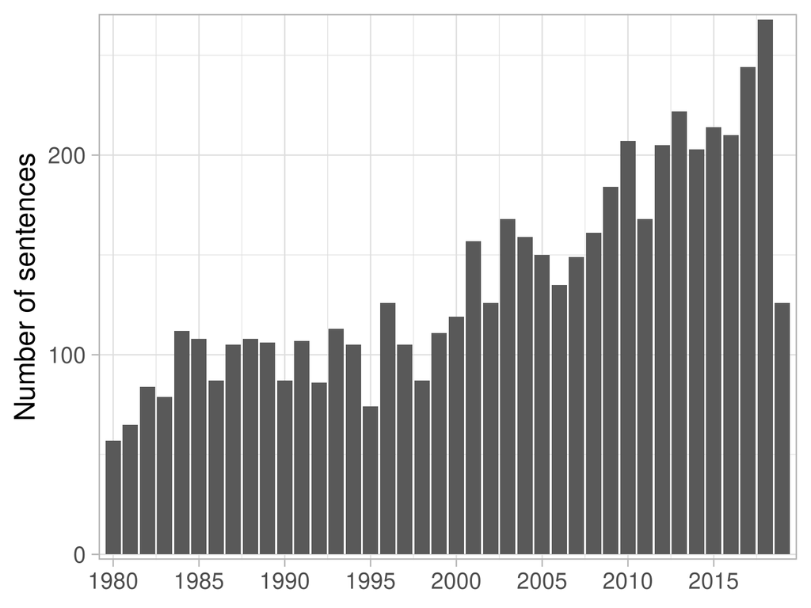

### Closest sentence from ‘rational’ and ‘rationality’ of the backbone community

| Sentence | Title | Year | Journal | Authors | Words Similarity |
| --- | --- | --- | --- | --- | --- |
| Whether or not one agrees that economic models ought always to assume rational behavior under uncertainty, i.e. | [Macroeconomics and Reality](http://www.jstor.org/stable/1912017) | 1980 | Econometrica | Christopher A. Sims | 0.805 |
| ‘Rational behavior, uncertain prospects, and expected utility.’ | [Nonlinear Preferences and Two-Stage Lotteries: Theories and Evidence](http://www.jstor.org/stable/2234674) | 1994 | The Economic Journal | Michele Bernasconi | 0.801 |
| Brav and Heaton discuss how this type of uncertainty exploits the distinction between “rationality” and “ratio nal expectations.” | [Corporate Political Contributions and Stock Returns](http://www.jstor.org/stable/25656307) | 2010 | The Journal of Finance | MICHAEL J. COOPER , HUSEYIN GULEN , ALEXEI V. OVTCHINNIKOV | 0.786 |
| This uncertainty is the result of rational economic reasoning. | [Rational Ignorance is not Bliss: When do Lazy Voters Learn from Decentralised Policy Experiments?](http://www.jstor.org/stable/23812528) | 2008 | Jahrbücher für Nationalökonomie und Statistik / Journal of Economics and Statistics | Jan Schnellenbach | 0.779 |
| But prices are only one of many dimensions along which uncertainty of expectations may complicate rational decision I. makring. | [Organizations and Markets](http://www.jstor.org/stable/1942684) | 1991 | The Journal of Economic Perspectives | Herbert A. Simon | 0.778 |
| Here it is maintained, in distinction from the first type of responses to the problem of uncertainty, that the rational actor model must be rejected more completely than these approaches suggest and, … | [Economic Sociology and Embeddedness: How Shall We Conceptualize Economic Action?](http://www.jstor.org/stable/4227931) | 2003 | Journal of Economic Issues | Jens Beckert | 0.776 |
| Hence, there is no reason why equilibrium, or even a tendency toward it, should be expected.8 Recently, the neoclassical response to the reality of uncertainty has been the development of the theory o… | [On Equilibrium](http://www.jstor.org/stable/4537808) | 1983 | Journal of Post Keynesian Economics | John F. Henry | 0.775 |
| Introduction RATIONALITY and uncertainty are concepts central to economic theorising. | [The Nature of Rational Choice and The Foundations of Statistics](http://www.jstor.org/stable/2663084) | 1991 | Oxford Economic Papers | Paul Anand | 0.774 |
| We seek to answer the question: How much irrationality must be permitted before speculation and agreements to disagree emerge in equilibrium?7 There are a number of errors that are typically made by d… | [Common Knowledge](http://www.jstor.org/stable/2138269) | 1992 | The Journal of Economic Perspectives | John Geanakoplos | 0.773 |
| The discussion of rationality under non-neoclassical uncertainty and its relation to conventions still awaits further progress in solving the problem of how to define rationality and how to relate it … | [Conventional and Unconventional Behavior under Uncertainty](http://www.jstor.org/stable/4538865) | 2003 | Journal of Post Keynesian Economics | David Dequech | 0.773 |
| Its purpose is to assess the usefulness and limitations of the notion of bounded rationality for a theory of economic behavior under fundamental uncertainty, in particular if such a theory emphasizes … | [Bounded Rationality, Institutions, and Uncertainty](http://www.jstor.org/stable/4227723) | 2001 | Journal of Economic Issues | David Dequech | 0.773 |
| Rationality and uncertainty. | [Utilities versus Rights to Publicly Provided Goods: Arguments and Evidence from Health Care Rationing](http://www.jstor.org/stable/2601645) | 2000 | Economica | Paul Anand , Allan Wailoo | 0.770 |
| In circumstances of certainty, agents are conventionally taken to have rational preferences if their preferences are complete and transitive, and to choose rationally if their preferences are rational… | [Taking Ethics Seriously: Economics and Contemporary Moral Philosophy](http://www.jstor.org/stable/2728513) | 1993 | Journal of Economic Literature | Daniel M. Hausman , Michael S. McPherson | 0.767 |
| Uncertainty Rational expectations and Keynesian uncertainty: a critique MALCOLM RUTHERFORD It has long been recognized that an individual’s expectations will affect his economic behavior. | [Rational Expectations and Keynesian Uncertainty: A Critique](http://www.jstor.org/stable/4537825) | 1984 | Journal of Post Keynesian Economics | Malcolm Rutherford | 0.766 |
| The concepts of endogenous uncertainty and rational beliefs, although formally distinct, are brought together in the last section of the paper. | [Speculative Trading with Rational Beliefs and Endogenous Uncertainty](http://www.jstor.org/stable/25055626) | 2003 | Economic Theory | Ho-Mou Wu , Wen-Chung Guo | 0.766 |
| Since both bounded rationality and “fundamental” uncertainty imply, at least in certain areas of decision-making, agents are unable to make optimizing choices whose payoffs are expected in the future,… | [Bounded Rationality Is Not Fundamental Uncertainty: A Post Keynesian Perspective](http://www.jstor.org/stable/4538749) | 2001 | Journal of Post Keynesian Economics | Stephen P. Dunn | 0.766 |
| rationality and uncertainty. | [INTENTIONAL APPLE-CHOICE BEHAVIORS:](http://www.jstor.org/stable/cahieconpolipape.65.97) | 2013 | Cahiers d’économie politique / Papers in Political Economy | Dorian Jullien | 0.765 |
| Some aspects of economic behavior under uncertainty should be considered arational, rather than irrational. | [Asset Choice, Liquidity Preference, and Rationality under Uncertainty](http://www.jstor.org/stable/4227537) | 2000 | Journal of Economic Issues | David Dequech | 0.764 |
| Here, inherent uncertainties in markets contribute to the human characteristic of bounded rationality. | [THE TRANSACTIONS COST THEORY OF VERTICAL INTEGRATION: LEASING IN THE MOTOR CARRIER INDUSTRY](http://www.jstor.org/stable/42747452) | 1993 | International Journal of Transport Economics / Rivista internazionale di economia dei trasporti | K.P. UPADHYAYA , F.G. MIXON Jr. | 0.761 |
| “Rational Expectations, Risk, Uncertainty and Market Responses.” | [Were Financial Crises Predictable?](http://www.jstor.org/stable/2078037) | 1994 | Journal of Money, Credit and Banking | Fabio Canova | 0.761 |

### Closest sentences of the backbone community’s centroid

| Sentence | Title | Year | Journal | Authors | Centroid Similarity |
| --- | --- | --- | --- | --- | --- |
| ‘Rational behavior, uncertain prospects, and expected utility.’ | [Nonlinear Preferences and Two-Stage Lotteries: Theories and Evidence](http://www.jstor.org/stable/2234674) | 1994 | The Economic Journal | Michele Bernasconi | 0.8261305 |
| Work in both economics and psychology provides evidence of behavior under uncertainty that is consistent with such a status quo bias. | [Uncertainty and Risk in Financial Markets](http://www.jstor.org/stable/3598943) | 2005 | Econometrica | Luca Rigotti , Chris Shannon | 0.8191157 |
| Several important topics have been discussed in greater depth elsewhere.9 My focus is on the psychology of imperfect rationality, not psychological determinants of rational risk aversion or time prefe… | [Investor Psychology and Asset Pricing](http://www.jstor.org/stable/2697808) | 2001 | The Journal of Finance | David Hirshleifer | 0.7983939 |
| “Rational Behavior, Uncertain Prospects, and Measurable Utility,” Econometrica, Apr. | [The Expected Utility Model: Its Variants, Purposes, Evidence and Limitations](http://www.jstor.org/stable/2724488) | 1982 | Journal of Economic Literature | Paul J. H. Schoemaker | 0.7898897 |
| Risk Perception, Learning, and Individual Behavior V. Kerry Smith and William H. Desvousges Economically rational behavior does not require that individuals make perfect decisions. | [Risk Perception, Learning, and Individual Behavior](http://www.jstor.org/stable/1241746) | 1988 | American Journal of Agricultural Economics | V. Kerry Smith , William H. Desvousges | 0.7826943 |
| The literature on ambiguity aversion blurs the distinctions between positive and normative economics, and between rational and irrational decision-making. | [Empirical Asset Pricing: Eugene Fama, Lars Peter Hansen, and Robert Shiller](http://www.jstor.org/stable/43673655) | 2014 | The Scandinavian Journal of Economics | John Y. Campbell | 0.7778322 |
| This leads me to consider how risk preferences, fairness concerns, subjects’ use of prior information, and bounded rationality might account for observed results. | [Durable-Goods Monopoly: Laboratory Market and Bargaining Experiments](http://www.jstor.org/stable/2601046) | 2000 | The RAND Journal of Economics | Stanley S. Reynolds | 0.7770836 |
| Fallibility, reflexivity, and the human uncertainty principle, Journal of Economic Methodology, vol. | [Forecasting errors by the Troika in the economic adjustment programme for Portugal](http://www.jstor.org/stable/44488763) | 2017 | Cambridge Journal of Economics | João Ferreira do Amaral, João Carlos Lopes | 0.7750480 |
| Conclusion In economic environments with uncertainty there is well-documented evidence that individuals often fail to behave optimally. | [Failures in Contingent Reasoning](http://www.jstor.org/stable/26789063) | 2019 | The American Economic Review | Alejandro Martínez-Marquina, Muriel Niederle , Emanuel Vespa | 0.7739092 |
| C. ALAN GARNER Uncertainty, human judgment, and economic decisions Conventional economic theory is built on what Keynes called “pretty, polite techniques.” | [Uncertainty, Human Judgment, and Economic Decisions](http://www.jstor.org/stable/4537676) | 1982 | Journal of Post Keynesian Economics | C. Alan Garner | 0.7720888 |
| “Paradoxes and Mechanisms for Choice under Risk.” Experimental Econ. | [Incentives in Experiments](http://www.jstor.org/stable/26550503) | 2018 | Journal of Political Economy | Yaron Azrieli , Christopher P. Chambers, Paul J. Healy | 0.7717370 |
| Probabilities vs. money: a test of some fundamental assumptions about rational decision making. | [Testing Different Stochastic Specifications of Risky Choice](http://www.jstor.org/stable/2555189) | 1998 | Economica | Graham Loomes, Robert Sugden | 0.7711152 |
| Contributions by Robison and Barry; Robison and Lev; and Robison, Barry, and Burghardt have considered several realistic institutions that may be important in explaining decisions under uncertainty by… | [Risk Analysis for Proprietors with Limited Liability: A Mean-Variance, Safety-First Synthesis](http://www.jstor.org/stable/40988130) | 1991 | Western Journal of Agricultural Economics | Robert A. Collins, Edward E. Gbur | 0.7696085 |
| Some aspects of economic behavior under uncertainty should be considered arational, rather than irrational. | [Asset Choice, Liquidity Preference, and Rationality under Uncertainty](http://www.jstor.org/stable/4227537) | 2000 | Journal of Economic Issues | David Dequech | 0.7693170 |
| This recognition may help to explain some important aspects of economic behavior which cannot be accounted for by the “static certainty” model. | [Modigliani’s Expectations](http://www.jstor.org/stable/40326404) | 2004 | Eastern Economic Journal | James E. Hartley | 0.7688545 |

### Closest sentences of each kmean cluster’s centroid composing the backbone community

#### Top terms 13_98: uncertainty, risk_aversion, price_uncertainty, risk_averse, aversion (1980-1989)

| Sentence | Title | Year | Journal | Authors | Distance to Centroid |
| --- | --- | --- | --- | --- | --- |
| The history of economic thought on the uncertainty ideology has taken us from Keynes through Tobin and on to rational expectations. | [Tobin on Keynes: A Suggested Interpretation](http://www.jstor.org/stable/4537828) | 1984 | Journal of Post Keynesian Economics | Dennis L. Weisman | 5.885424 |
| Dreze, J. H. Essays on Economic Decisions Under Uncertainty. | [Probability and Uncertainty in Economic Analysis](http://www.jstor.org/stable/4538115) | 1988 | Journal of Post Keynesian Economics | Tony Lawson | 6.736362 |
| In Uncertainty and Expectations in Economics: Essays in Honor of G. L. S. Shackle, edited by C. F. Carter and J. L. Ford. | [Harry G. Johnson: A Bibliography](http://www.jstor.org/stable/1837165) | 1984 | Journal of Political Economy | Vicky M. Longawa | 6.743164 |
| Uncertainty Rational expectations and Keynesian uncertainty: a critique MALCOLM RUTHERFORD It has long been recognized that an individual’s expectations will affect his economic behavior. | [Rational Expectations and Keynesian Uncertainty: A Critique](http://www.jstor.org/stable/4537825) | 1984 | Journal of Post Keynesian Economics | Malcolm Rutherford | 6.867933 |
| _ , Economic Decisions under Uncertainty, second, English edition, Amsterdam, New York, and Oxford: North-Holland Publishing Company, 1983, first edition: Okonomische Entscheidungen bei UngewiB3heit, … | [Two-Moment Decision Models and Expected Utility Maximization: Comment](http://www.jstor.org/stable/1806872) | 1989 | The American Economic Review | Hans-Werner Sinn | 6.997629 |

#### Top terms 13_120: irreversibility_uncertainty, uncertainty, risk_aversion, aversion, irreversibility (1990-1999)

| Sentence | Title | Year | Journal | Authors | Distance to Centroid |
| --- | --- | --- | --- | --- | --- |
| The literature on choice under pure-uncertainty shows that the ability to formulate the outcomes in terms of probabilities is not a necessary condition for rationality. | [How to Decide When Experts Disagree: Uncertainty-Based Choice Rules in Environmental Policy](http://www.jstor.org/stable/3147241) | 1997 | Land Economics | Richard T. Woodward, Richard C. Bishop | 6.933928 |
| Hey argues as follows ’… the Economics of Uncertainty has been sidetracked by the allure of backward induction from the serious consideration of many important real-life problems. | [Attainable Non-Optimality or Unattainable Optimality: A New Approach to Stochastic Life Cycle Problems](http://www.jstor.org/stable/2234335) | 1993 | The Economic Journal | James Pemberton | 6.968097 |
| INTRODUCTION THE ECONOMIC THEORY OF BEHAVIOR under uncertainty forms the basis for much of modern finance and monetary theory. | [Common Persistence in Conditional Variances](http://www.jstor.org/stable/2951782) | 1993 | Econometrica | Tim Bollerslev , Robert F. Engle | 7.079470 |
| Introduction RATIONALITY and uncertainty are concepts central to economic theorising. | [The Nature of Rational Choice and The Foundations of Statistics](http://www.jstor.org/stable/2663084) | 1991 | Oxford Economic Papers | Paul Anand | 7.133988 |
| Bewley’s distinction between risk and uncertainty is extremely interesting in its own right but the incompleteness of agents’ preferences would make the analysis of the present paper difficult. | [Standard Securities](http://www.jstor.org/stable/2297995) | 1992 | The Review of Economic Studies | Douglas Gale | 7.151889 |

#### Top terms 13_131: fundamental_uncertainty, uncertainty, irreversibility_uncertainty, model_uncertainty, endogenous_uncertainty (2000-2009)

| Sentence | Title | Year | Journal | Authors | Distance to Centroid |
| --- | --- | --- | --- | --- | --- |
| Davidson’s concept of “fundamental” uncertainty is conceptually distinct from the “behavioral” uncertainty to which proponents of the bounded rationality approach to the study of economic decision-mak… | [Bounded Rationality Is Not Fundamental Uncertainty: A Post Keynesian Perspective](http://www.jstor.org/stable/4538749) | 2001 | Journal of Post Keynesian Economics | Stephen P. Dunn | 6.511763 |
| An abridged version of this paper is forthcoming as a chapter entitled “Uncertainty and Expectations,” in Richard P.F. | [Alternative Keynesian and Post Keynesian Perspectives on Uncertainty and Expectations](http://www.jstor.org/stable/4538748) | 2001 | Journal of Post Keynesian Economics | J. Barkley Rosser, Jr. | 6.547393 |
| Since both bounded rationality and “fundamental” uncertainty imply, at least in certain areas of decision-making, agents are unable to make optimizing choices whose payoffs are expected in the future,… | [Bounded Rationality Is Not Fundamental Uncertainty: A Post Keynesian Perspective](http://www.jstor.org/stable/4538749) | 2001 | Journal of Post Keynesian Economics | Stephen P. Dunn | 6.662731 |
| If, as suggested by the certainty ef fect, the mere presence of uncertainty causes individuals to discount their valuation of a prospect, then their valuation of a gamble will depend on whether it is … | [Risk Averters That Love Risk? Marginal Risk Aversion in Comparison to a Reference Gamble](http://www.jstor.org/stable/20616223) | 2009 | American Journal of Agricultural Economics | David R. Just , Travis J. Lybbert | 6.895643 |
| Work in both economics and psychology provides evidence of behavior under uncertainty that is consistent with such a status quo bias. | [Uncertainty and Risk in Financial Markets](http://www.jstor.org/stable/3598943) | 2005 | Econometrica | Luca Rigotti , Chris Shannon | 6.907920 |

#### Top terms 13_134: risk_aversion, aversion, risk_averse, risk, averse (2000-2009)

| Sentence | Title | Year | Journal | Authors | Distance to Centroid |
| --- | --- | --- | --- | --- | --- |
| The potential for heterogeneity in risk preference is considered below. | [Health Insurance, Treatment and Outcomes: Using Auto Accidents as Health Shocks](http://www.jstor.org/stable/40042901) | 2005 | The Review of Economics and Statistics | Joseph J. Doyle Jr. | 6.801209 |
| Cornes, R.C., Hartley, R.: Risk aversion, heterogeneity and contests. | [Asymmetric Contests with General Technologies](http://www.jstor.org/stable/25055990) | 2005 | Economic Theory | Richard Cornes, Roger Hartley | 6.979615 |
| The following proposition shows that agents with optimal expectations can have a preference for skewness that is stronger than their aversion to risk. | [Optimal Expectations](http://www.jstor.org/stable/4132707) | 2005 | The American Economic Review | Markus K. Brunnermeier, Jonathan A. Parker | 6.994831 |
| Unlike this literature, we consider risk aversion. | [Private Information and Intertemporal Job Assignments](http://www.jstor.org/stable/3700650) | 2006 | The Review of Economic Studies | Edward Simpson Prescott, Robert M. Townsend | 6.997900 |
| Foundations of Rational Choice Under Risk. | [Utilities versus Rights to Publicly Provided Goods: Arguments and Evidence from Health Care Rationing](http://www.jstor.org/stable/2601645) | 2000 | Economica | Paul Anand , Allan Wailoo | 7.082175 |

#### Top terms 13_146: uncertainty, ambiguity, irreversibility_uncertainty, ambiguity_aversion, fundamental_uncertainty (2010-2019)

| Sentence | Title | Year | Journal | Authors | Distance to Centroid |
| --- | --- | --- | --- | --- | --- |
| Economic decisions are made in an environment of uncertainty. | [Modeling financial crises: a schematic approach](http://www.jstor.org/stable/20798381) | 2010 | Journal of Post Keynesian Economics | JOHN T. HARVEY | 6.161282 |
| Brav and Heaton discuss how this type of uncertainty exploits the distinction between “rationality” and “ratio nal expectations.” | [Corporate Political Contributions and Stock Returns](http://www.jstor.org/stable/25656307) | 2010 | The Journal of Finance | MICHAEL J. COOPER , HUSEYIN GULEN , ALEXEI V. OVTCHINNIKOV | 6.676336 |
| ‘Decisions under uncertainty: comment’, Quarterly journal of Economics, vol. | [YOU NEED TO RECOGNISE AMBIGUITY TO AVOID IT](http://www.jstor.org/stable/45023183) | 2018 | The Economic Journal | Chew Soo Hong , Mark Ratchford, Jacob S. Sagi | 6.695649 |
| It is concluded that rather than recoiling from uncertainty to the extent of not addressing it seriously, economists would do better by accepting its significance and developing methodologies and theo… | [Addressing uncertainty in economics and the economy](http://www.jstor.org/stable/24694944) | 2015 | Cambridge Journal of Economics | Sheila C. Dow | 6.735222 |
| Choice under uncertainty, Journal of Economic Perspectives, vol. | [On Keynes as an investor](http://www.jstor.org/stable/23602200) | 2013 | Cambridge Journal of Economics | J. E. Woods | 6.762092 |

#### Top terms 13_153: risk_aversion, aversion, risk, risk_averse, risk_preferences (2010-2019)

| Sentence | Title | Year | Journal | Authors | Distance to Centroid |
| --- | --- | --- | --- | --- | --- |
| Risk and Preferences. | [Generalized Systematic Risk](http://www.jstor.org/stable/43948915) | 2016 | American Economic Journal: Microeconomics | Ohad Kadan, Fang Liu , Suying Liu | 6.185081 |
| “Risk Aversion and Expected Utility Theory: An Delavande, Adeline. | [Estimating Risk Preferences in the Field](http://www.jstor.org/stable/26494195) | 2018 | Journal of Economic Literature | Levon Barseghyan , Francesca Molinari , Ted O’Donoghue , Joshua C. Teitelbaum | 6.452437 |
| Throughout the paper, it will be assumed that individuals’ risk preferences are fixed and known, whereas individuals’ beliefs may vary. | [Fair social decision under uncertainty and belief disagreements](http://www.jstor.org/stable/45200145) | 2019 | Economic Theory | Takashi Hayashi , Michele Lombardi | 6.490524 |
| 2009; Andrikogiannopoulou 201 ETAL: THE NATURE OF RISK PREFERENCES 2502 We conclude in Section VI by discussing certain implications and limitations of our study. | [The Nature of Risk Preferences: Evidence from Insurance Choices](http://www.jstor.org/stable/42920658) | 2013 | The American Economic Review | Levon Barseghyan , Francesca Molinari , Ted O’Donoghue , Joshua C. Teitelbaum | 6.603697 |
| In this respect, risk-sensitive preferences are subject to the dilemma discussed above, i.e. | [Risk Aversion and the Value of Life](http://www.jstor.org/stable/26543863) | 2017 | The Review of Economic Studies | JUAN CARLOS CÓRDOBA, MARLA RIPOLL | 6.654455 |

### Top articles (most sentences) of the backbone cluster

| Title | Year | Journal | Authors | Number sentences | Words Similarity |
| --- | --- | --- | --- | --- | --- |
| [Estimating Risk Preferences in the Field](http://www.jstor.org/stable/26494195) | 2018 | Journal of Economic Literature | Levon Barseghyan , Francesca Molinari , Ted O’Donoghue , Joshua C. Teitelbaum | 16 | 0.605 |
| [Modeling Risk Aversion in Economics](http://www.jstor.org/stable/26409426) | 2018 | The Journal of Economic Perspectives | Ted O’Donoghue , Jason Somerville | 15 | 0.618 |
| [Alternative Keynesian and Post Keynesian Perspectives on Uncertainty and Expectations](http://www.jstor.org/stable/4538748) | 2001 | Journal of Post Keynesian Economics | J. Barkley Rosser, Jr. | 14 | 0.618 |
| [Uncertainty and Economic Sociology: A Preliminary Discussion](http://www.jstor.org/stable/3487809) | 2003 | The American Journal of Economics and Sociology | David Dequech | 14 | 0.632 |
| [Keynesian Uncertainty in Credit Markets](http://www.jstor.org/stable/4538498) | 1996 | Journal of Post Keynesian Economics | Penny Neal | 13 | 0.623 |
| [Bounded Rationality, Institutions, and Uncertainty](http://www.jstor.org/stable/4227723) | 2001 | Journal of Economic Issues | David Dequech | 13 | 0.668 |
| [Bounded Rationality Is Not Fundamental Uncertainty: A Post Keynesian Perspective](http://www.jstor.org/stable/4538749) | 2001 | Journal of Post Keynesian Economics | Stephen P. Dunn | 13 | 0.668 |
| [The Concept of Uncertainty in Post Keynesian Theory and in Institutional Economics](http://www.jstor.org/stable/4228172) | 2005 | Journal of Economic Issues | Fernando Ferrari-Filho , Octavio Augusto Camargo Conceição | 13 | 0.617 |
| [Addressing uncertainty in economics and the economy](http://www.jstor.org/stable/24694944) | 2015 | Cambridge Journal of Economics | Sheila C. Dow | 13 | 0.597 |
| [Probability and Uncertainty in Economic Analysis](http://www.jstor.org/stable/4538115) | 1988 | Journal of Post Keynesian Economics | Tony Lawson | 12 | 0.627 |
| [Keynes, uncertainty and interest rates](http://www.jstor.org/stable/23600357) | 2002 | Cambridge Journal of Economics | Brian Weatherson | 11 | 0.610 |
| [Conventional and Unconventional Behavior under Uncertainty](http://www.jstor.org/stable/4538865) | 2003 | Journal of Post Keynesian Economics | David Dequech | 11 | 0.670 |
| [A Bayesian Approach to Uncertainty Aversion](http://www.jstor.org/stable/3700659) | 2005 | The Review of Economic Studies | Yoram Halevy , Vincent Feltkamp | 11 | 0.615 |
| [CHOICE UNDER UNCERTAINTY: EVIDENCE FROM ETHIOPIA, INDIA AND UGANDA](http://www.jstor.org/stable/27765763) | 2010 | The Economic Journal | Glenn W. Harrison , Steven J. Humphrey, Arjan Verschoor | 11 | 0.614 |
| [Risk, ambiguity, and state-preference theory](http://www.jstor.org/stable/41486005) | 2011 | Economic Theory | Robert Nau | 11 | 0.594 |

### Top articles (most sentences) of the cluster for each time window

#### Top articles for 13_98: uncertainty, risk_aversion, price_uncertainty, risk_averse, aversion (1980-1989)

| Title | Year | Journal | Authors | Number sentences | Words Similarity |
| --- | --- | --- | --- | --- | --- |
| [Probability and Uncertainty in Economic Analysis](http://www.jstor.org/stable/4538115) | 1988 | Journal of Post Keynesian Economics | Tony Lawson | 12 | 0.627 |
| [Uncertainty, Indicative Planning, and Industrial Policy](http://www.jstor.org/stable/4225417) | 1984 | Journal of Economic Issues | Allan G. Gruchy | 10 | 0.602 |
| [Uncertainty and Economic Analysis](http://www.jstor.org/stable/2233256) | 1985 | The Economic Journal | Tony Lawson | 10 | 0.635 |
| [Whither Uncertainty?](http://www.jstor.org/stable/2232647) | 1983 | The Economic Journal | John D. Hey | 8 | 0.623 |
| [On Relational Structures and Non-Equilibrium in Economic Theory](http://www.jstor.org/stable/40325004) | 1985 | Eastern Economic Journal | Douglas Vickers | 8 | 0.620 |
| [Efficiency and Speculation in a Model with Price-Contingent Contracts](http://www.jstor.org/stable/1911130) | 1981 | Econometrica | Lars E. O. Svensson | 7 | 0.599 |
| [Choice Under Uncertainty: Problems Solved and Unsolved](http://www.jstor.org/stable/1942952) | 1987 | The Journal of Economic Perspectives | Mark J. Machina | 7 | 0.615 |
| [Troublesome Probability and Economics](http://www.jstor.org/stable/4538050) | 1987 | Journal of Post Keynesian Economics | Robin Rowley, Omar Hamouda | 7 | 0.607 |
| [Deficient Foresight: A Troublesome Theme in Keynesian Economics](http://www.jstor.org/stable/1831546) | 1982 | The American Economic Review | Alan Coddington | 6 | 0.605 |
| [Uncertainty, Efficiency, and Economic Planning in Keynesian Economics](http://www.jstor.org/stable/4537908) | 1985 | Journal of Post Keynesian Economics | Saul Estrin , Peter Holmes | 6 | 0.615 |

#### Top articles for 13_120: irreversibility_uncertainty, uncertainty, risk_aversion, aversion, irreversibility (1990-1999)

| Title | Year | Journal | Authors | Number sentences | Words Similarity |
| --- | --- | --- | --- | --- | --- |
| [Keynesian Uncertainty in Credit Markets](http://www.jstor.org/stable/4538498) | 1996 | Journal of Post Keynesian Economics | Penny Neal | 13 | 0.623 |
| [Uncertainty, Expectations, and the Future: If We Don’t Know the Answers, What Are the Questions?](http://www.jstor.org/stable/4538371) | 1993 | Journal of Post Keynesian Economics | Thomas I. Palley | 10 | 0.617 |
| [Endogenous Uncertainty in a General Equilibrium Model with Price Contingent Contracts](http://www.jstor.org/stable/25054983) | 1996 | Economic Theory | Mordecai Kurz, Ho-Mou Wu | 10 | 0.613 |
| [Is Probability Theory Relevant for Uncertainty? A Post Keynesian Perspective](http://www.jstor.org/stable/1942706) | 1991 | The Journal of Economic Perspectives | Paul Davidson | 8 | 0.602 |
| [Global Environmental Risks](http://www.jstor.org/stable/2138501) | 1993 | The Journal of Economic Perspectives | Graciela Chichilnisky, Geoffrey Heal | 7 | 0.601 |
| [Keynesian uncertainty and liquidity preference](http://www.jstor.org/stable/24231904) | 1994 | Cambridge Journal of Economics | Jochen Runde | 7 | 0.609 |
| [The appeal of neoclassical economics: some insights from Keynes’s epistemology](http://www.jstor.org/stable/23600205) | 1995 | Cambridge Journal of Economics | Sheila C. Dow | 7 | 0.605 |
| [How to Decide When Experts Disagree: Uncertainty-Based Choice Rules in Environmental Policy](http://www.jstor.org/stable/3147241) | 1997 | Land Economics | Richard T. Woodward, Richard C. Bishop | 7 | 0.615 |
| [THE ‘TRUE’ HYPOTHESIS OF DANIEL BERNOULLI: WHAT DID THE MARGINALISTS REALLY KNOW?](http://www.jstor.org/stable/23722513) | 1998 | History of Economic Ideas | Nicola Giocoli | 7 | 0.614 |
| [Keynes’s critiques of Moore: philosophical foundations of Keynes’s economics](http://www.jstor.org/stable/23598167) | 1991 | Cambridge Journal of Economics | J. B. Davis | 6 | 0.616 |

#### Top articles for 13_131: fundamental_uncertainty, uncertainty, irreversibility_uncertainty, model_uncertainty, endogenous_uncertainty (2000-2009)

| Title | Year | Journal | Authors | Number sentences | Words Similarity |
| --- | --- | --- | --- | --- | --- |
| [Alternative Keynesian and Post Keynesian Perspectives on Uncertainty and Expectations](http://www.jstor.org/stable/4538748) | 2001 | Journal of Post Keynesian Economics | J. Barkley Rosser, Jr. | 14 | 0.618 |
| [Uncertainty and Economic Sociology: A Preliminary Discussion](http://www.jstor.org/stable/3487809) | 2003 | The American Journal of Economics and Sociology | David Dequech | 14 | 0.632 |
| [Bounded Rationality, Institutions, and Uncertainty](http://www.jstor.org/stable/4227723) | 2001 | Journal of Economic Issues | David Dequech | 13 | 0.668 |
| [Bounded Rationality Is Not Fundamental Uncertainty: A Post Keynesian Perspective](http://www.jstor.org/stable/4538749) | 2001 | Journal of Post Keynesian Economics | Stephen P. Dunn | 13 | 0.668 |
| [The Concept of Uncertainty in Post Keynesian Theory and in Institutional Economics](http://www.jstor.org/stable/4228172) | 2005 | Journal of Economic Issues | Fernando Ferrari-Filho , Octavio Augusto Camargo Conceição | 13 | 0.617 |
| [Conventional and Unconventional Behavior under Uncertainty](http://www.jstor.org/stable/4538865) | 2003 | Journal of Post Keynesian Economics | David Dequech | 11 | 0.670 |
| [Keynes, uncertainty and interest rates](http://www.jstor.org/stable/23600357) | 2002 | Cambridge Journal of Economics | Brian Weatherson | 10 | 0.612 |
| [Economic Sociology and Embeddedness: How Shall We Conceptualize Economic Action?](http://www.jstor.org/stable/4227931) | 2003 | Journal of Economic Issues | Jens Beckert | 10 | 0.668 |
| [Uncertainty and Monetary Policy](http://www.jstor.org/stable/3488928) | 2004 | Oxford Economic Papers | Sheila C. Dow | 10 | 0.626 |
| [Uncertainty and Probability in Institutional Economics](http://www.jstor.org/stable/25511259) | 2007 | Journal of Economic Issues | Matthew C. Wilson | 10 | 0.610 |

#### Top articles for 13_134: risk_aversion, aversion, risk_averse, risk, averse (2000-2009)

| Title | Year | Journal | Authors | Number sentences | Words Similarity |
| --- | --- | --- | --- | --- | --- |
| [Individual Preferences, Monetary Gambles, and Stock Market Participation: A Case for Narrow Framing](http://www.jstor.org/stable/30034331) | 2006 | The American Economic Review | Nicholas Barberis, Ming Huang , Richard H. Thaler | 10 | 0.606 |
| [Learning to Reoptimize Consumption at New Income Levels: A Rationale for Prospect Theory](http://www.jstor.org/stable/40004870) | 2004 | Journal of the European Economic Association | Markus K. Brunnermeier | 9 | 0.633 |
| [Comparing Risk Aversion in a Probability Triangle](http://www.jstor.org/stable/25055404) | 2001 | Economic Theory | Robert A. Becker | 7 | 0.589 |
| [Misery Loves Company: Equilibrium Portfolios with Heterogeneous Consumption Externalities](http://www.jstor.org/stable/3663623) | 2004 | International Economic Review | Christian Gollier | 7 | 0.608 |
| [Political Decision of Risk Reduction: The Role of Trust](http://www.jstor.org/stable/40270746) | 2009 | Public Choice | Meglena Jeleva , Stephane Rossignol | 7 | 0.601 |
| [Risk Aversion and Expected-Utility Theory: A Calibration Theorem](http://www.jstor.org/stable/2999450) | 2000 | Econometrica | Matthew Rabin | 6 | 0.613 |
| [Anomalies: Risk Aversion](http://www.jstor.org/stable/2696549) | 2001 | The Journal of Economic Perspectives | Matthew Rabin , Richard H. Thaler | 6 | 0.622 |
| [Narrow Bracketing and Dominated Choices](http://www.jstor.org/stable/25592517) | 2009 | The American Economic Review | Matthew Rabin , Georg Weizsäcker | 6 | 0.598 |
| [Developments in Non-Expected Utility Theory: The Hunt for a Descriptive Theory of Choice under Risk](http://www.jstor.org/stable/2565292) | 2000 | Journal of Economic Literature | Chris Starmer | 5 | 0.608 |
| [The Market Value of Reducing Cancer Risk: Hedonic Housing Prices with Changing Information](http://www.jstor.org/stable/1061672) | 2002 | Southern Economic Journal | Ted Gayer , James T. Hamilton, W. Kip Viscusi | 5 | 0.630 |

#### Top articles for 13_146: uncertainty, ambiguity, irreversibility_uncertainty, ambiguity_aversion, fundamental_uncertainty (2010-2019)

| Title | Year | Journal | Authors | Number sentences | Words Similarity |
| --- | --- | --- | --- | --- | --- |
| [Addressing uncertainty in economics and the economy](http://www.jstor.org/stable/24694944) | 2015 | Cambridge Journal of Economics | Sheila C. Dow | 11 | 0.599 |
| [Uncertainty: A Typology and Refinements of Existing Concepts](http://www.jstor.org/stable/23071564) | 2011 | Journal of Economic Issues | David Dequech | 10 | 0.596 |
| [Keynes as the first behavioral economist: the case of the attribute-substitution heuristic](http://www.jstor.org/stable/43671478) | 2014 | Journal of Post Keynesian Economics | THODORIS T. KOUTSOBINAS | 10 | 0.637 |
| [KEYNES ON PROBABILITY AND DECISION: EVIDENCE FROM THE CORRESPONDENCE WITH HUGH TOWNSHEND](http://www.jstor.org/stable/43924238) | 2015 | History of Economic Ideas | Carlo Zappia | 10 | 0.599 |
| [De Finetti on uncertainty](http://www.jstor.org/stable/23601809) | 2014 | Cambridge Journal of Economics | Alberto Feduzi, Jochen Runde , Carlo Zappia | 8 | 0.616 |
| [Ambiguity Aversion with Three or More Outcomes](http://www.jstor.org/stable/43495358) | 2014 | The American Economic Review | Mark J. Machina | 7 | 0.599 |
| [Uncertainty and Trade Agreements](http://www.jstor.org/stable/43949030) | 2015 | American Economic Journal: Microeconomics | Nuno Limão , Giovanni Maggi | 7 | 0.628 |
| [Incorporating Outcome Uncertainty and Prior Outcome Beliefs in Stated Preferences](http://www.jstor.org/stable/24773530) | 2015 | Land Economics | Thomas Lundhede , Jette Bredahl Jacobsen, Nick Hanley , Niels Strange , Bo Jellesmark Thorsen | 7 | 0.611 |
| [A rejoinder to O’Donnell’s critique of the ergodic/nonergodic explanation of Keynes’s concept of uncertainty](http://www.jstor.org/stable/48540592) | 2015 | Journal of Post Keynesian Economics | PAUL DAVIDSON | 7 | 0.595 |
| [Survey Measurement of Probabilistic Macroeconomic Expectations](http://www.jstor.org/stable/26556599) | 2017 | NBER Macroeconomics Annual | Charles F. Manski | 7 | 0.615 |

#### Top articles for 13_153: risk_aversion, aversion, risk, risk_averse, risk_preferences (2010-2019)

| Title | Year | Journal | Authors | Number sentences | Words Similarity |
| --- | --- | --- | --- | --- | --- |
| [Modeling Risk Aversion in Economics](http://www.jstor.org/stable/26409426) | 2018 | The Journal of Economic Perspectives | Ted O’Donoghue , Jason Somerville | 15 | 0.618 |
| [Estimating Risk Preferences in the Field](http://www.jstor.org/stable/26494195) | 2018 | Journal of Economic Literature | Levon Barseghyan , Francesca Molinari , Ted O’Donoghue , Joshua C. Teitelbaum | 14 | 0.604 |
| [Risk, ambiguity, and state-preference theory](http://www.jstor.org/stable/41486005) | 2011 | Economic Theory | Robert Nau | 10 | 0.593 |
| [SALIENCE THEORY OF CHOICE UNDER RISK](http://www.jstor.org/stable/23251985) | 2012 | The Quarterly Journal of Economics | Pedro Bordalo , Nicola Gennaioli, Andrei Shleifer | 10 | 0.612 |
| [THE FOURFOLD PATTERN OF RISK ATTITUDES IN CHOICE AND PRICING TASKS](http://www.jstor.org/stable/40784579) | 2010 | The Economic Journal | William T. Harbaugh, Kate Krause , Lise Vesterlund | 9 | 0.588 |
| [Is there a plausible theory for decision under risk? A dual calibration critique](http://www.jstor.org/stable/43562925) | 2013 | Economic Theory | James C. Cox , Vjollca Sadiraj , Bodo Vogt , Utteeyo Dasgupta | 8 | 0.618 |
| [CHOICE UNDER UNCERTAINTY: EVIDENCE FROM ETHIOPIA, INDIA AND UGANDA](http://www.jstor.org/stable/27765763) | 2010 | The Economic Journal | Glenn W. Harrison , Steven J. Humphrey, Arjan Verschoor | 7 | 0.606 |
| [Are Risk Preferences Stable across Contexts? Evidence from Insurance Data](http://www.jstor.org/stable/29783684) | 2011 | The American Economic Review | Levon Barseghyan , Jeffrey Prince , Joshua C. Teitelbaum | 7 | 0.596 |
| [IMPACT OF ECONOMICS LEARNING ON RISK PREFERENCES AND RATIONALITY: AN EMPIRICAL INVESTIGATION](http://www.jstor.org/stable/43664816) | 2013 | The American Economist | Zhengyi Zhou | 7 | 0.641 |
| [Higher Order Risk Attitudes, Demographics, and Financial Decisions](http://www.jstor.org/stable/43551674) | 2014 | The Review of Economic Studies | CHARLES N. NOUSSAIR, STEFAN T. TRAUTMANN, GIJS VAN DE KUILEN | 7 | 0.604 |

### Most cited references in the backbone community

| First Author | Year | Journal | Citation by article | Citation by sentence |
| --- | --- | --- | --- | --- |
| KAHNEMAN-D | 1979 | ECONOMETRICA | 120 | 3960 |
| ELLSBERG-D | 1961 | Q J EC | 46 | 1564 |
| MUTH-J | 1961 | ECONOMETRICA | 22 | 616 |
| TVERSKY-A | 1992 | J RISK UNCERTAINTY | 37 | 592 |
| PRATT-J | 1964 | ECONOMETRICA | 43 | 473 |
| HOLT-C | 2002 | AM ECON REV | 36 | 432 |
| GILBOA-I | 1989 | J MATH ECON | 47 | 376 |
| EPSTEIN-L | 1989 | ECONOMETRICA | 37 | 148 |
| ROSSER-J | 1999 | J ECON PERSPECT | 4 | 108 |
| LAWSON-T | 1985 | ECON J | 4 | 92 |
| SCHMEIDLER-D | 1989 | ECONOMETRICA | 13 | 91 |
| MEHRA-R | 1985 | J MONETARY EC | 28 | 84 |
| DEQUECH-D | 1999 | J POST KEYNESIAN EC | 4 | 80 |
| ROTHSCHILD-M | 1970 | J ECONOMIC THEORY | 24 | 72 |
| LUCAS-R | 1972 | J EC THEORY | 21 | 63 |

| First Author | Year | Journal | Citation by article | Citation by sentence |
| --- | --- | --- | --- | --- |
| SAVAGE-L | 1954 | FDN STAT | 113 | 6102 |
| KNIGHT-F | 1921 | RISK UNCERTAINTY PRO | 97 | 4753 |
| KEYNES-J | 1973 | COLLECTED WRITINGS J | 126 | 4536 |
| KEYNES-J | 1936 | GEN THEORY EMPLOYMEN | 67 | 1876 |
| KEYNES-J | 1936 | GENERAL THEORY EMPLO | 91 | 1547 |
| KEYNES-J | 1973 | Q J EC | 30 | 330 |
| LAWSON-T | 1997 | EC REALITY | 23 | 299 |
| DAVIDSON-P | 1994 | POST KEYNESIAN MACRO | 18 | 252 |
| GOLLIER-C | 2001 | EC RISK TIME | 18 | 252 |
| ARROW-K | 1971 | GENERAL COMPETITIVE | 34 | 238 |
| DAVIDSON-P | 1978 | MONEY REAL WORLD | 17 | 204 |
| HICKS-J | 1979 | CAUSALITY EC | 17 | 170 |
| LUCAS-R | 1981 | STUDIES BUSINESS CYC | 13 | 156 |
| KNIGHT-F | 1921 | UNCERTAINTY PROFIT | 13 | 130 |
| ARROW-K | 1971 | ESSAYS THEORY RISK B | 16 | 112 |

### Most cited references per kmean clusters

#### Top references 13_98: uncertainty, risk_aversion, price_uncertainty, risk_averse, aversion (1980-1989)

| First Author | Year | Journal | Citation by article | Citation by sentence |
| --- | --- | --- | --- | --- |
| PRATT-J | 1964 | ECONOMETRICA | 19 | 19 |
| ROTHSCHILD-M | 1970 | J ECONOMIC THEORY | 9 | 18 |
| SANDMO-A | 1971 | AM EC REV | 8 | 16 |
| LUCAS-R | 1972 | J EC THEORY | 15 | 15 |
| ROTHSCHILD-M | 1970 | J ECONOMIC THEORY | 15 | 15 |
| PRATT-J | 1964 | ECONOMETRICA | 7 | 14 |
| MUTH-J | 1961 | ECONOMETRICA | 14 | 14 |
| LUCAS-R | 1973 | AER | 13 | 13 |
| KAHNEMAN-D | 1979 | ECONOMETRICA | 6 | 12 |
| KAHNEMAN-D | 1979 | ECONOMETRICA | 4 | 12 |

| First Author | Year | Journal | Citation by article | Citation by sentence |
| --- | --- | --- | --- | --- |
| KEYNES-J | 1973 | COLLECTED WRITINGS J | 38 | 380 |
| KEYNES-J | 1936 | GENERAL THEORY EMPLO | 53 | 371 |
| KNIGHT-F | 1921 | RISK UNCERTAINTY PRO | 26 | 312 |
| ARROW-K | 1971 | GENERAL COMPETITIVE | 34 | 238 |
| SAVAGE-L | 1954 | FDN STAT | 19 | 228 |
| DAVIDSON-P | 1978 | MONEY REAL WORLD | 17 | 204 |
| HICKS-J | 1979 | CAUSALITY EC | 17 | 170 |
| LUCAS-R | 1981 | STUDIES BUSINESS CYC | 13 | 156 |

#### Top references 13_120: irreversibility_uncertainty, uncertainty, risk_aversion, aversion, irreversibility (1990-1999)

| First Author | Year | Journal | Citation by article | Citation by sentence |
| --- | --- | --- | --- | --- |
| KAHNEMAN-D | 1979 | ECONOMETRICA | 10 | 20 |
| BERNANKE-B | 1983 | QJE | 9 | 18 |
| ELLSBERG-D | 1961 | Q J EC | 4 | 16 |
| PINDYCK-R | 1988 | AM ECON REV | 8 | 16 |
| MCDONALD-R | 1986 | Q J EC | 8 | 16 |
| PINDYCK-R | 1991 | J ECON LIT | 15 | 15 |
| CASS-D | 1983 | JPE | 5 | 15 |
| ARROW-K | 1974 | Q J ECON | 2 | 14 |
| ELLSBERG-D | 1961 | Q J EC | 7 | 14 |
| ELLSBERG-D | 1961 | Q J EC | 2 | 14 |

| First Author | Year | Journal | Citation by article | Citation by sentence |
| --- | --- | --- | --- | --- |
| KEYNES-J | 1973 | COLLECTED WRITINGS J | 46 | 598 |
| KEYNES-J | 1936 | GENERAL THEORY EMPLO | 38 | 380 |
| SAVAGE-L | 1954 | FDN STAT | 34 | 340 |
| KNIGHT-F | 1921 | RISK UNCERTAINTY PRO | 23 | 299 |

#### Top references 13_131: fundamental_uncertainty, uncertainty, irreversibility_uncertainty, model_uncertainty, endogenous_uncertainty (2000-2009)

| First Author | Year | Journal | Citation by article | Citation by sentence |
| --- | --- | --- | --- | --- |
| DAVIDSON-P | 1991 | J ECON PERSPECT | 3 | 30 |
| RUNDE-J | 1990 | ECON PHILOS | 3 | 30 |
| ROSSER-J | 1999 | J ECON PERSPECT | 2 | 28 |
| SIMON-H | 1959 | AM EC REV | 2 | 26 |
| LAWSON-T | 1985 | ECON J | 2 | 26 |
| MINSKY-H | 1996 | J ECON ISSUES | 2 | 26 |
| DAVIDSON-P | 1996 | J POST KEYNESIAN EC | 2 | 26 |
| SENT-E | 1997 | CAMBRIDGE J ECON | 2 | 26 |
| ROSSER-J | 1999 | J ECON PERSPECT | 2 | 26 |
| GILBOA-I | 1989 | J MATH ECON | 23 | 23 |

| First Author | Year | Journal | Citation by article | Citation by sentence |
| --- | --- | --- | --- | --- |
| KEYNES-J | 1973 | COLLECTED WRITINGS J | 42 | 546 |
| KEYNES-J | 1936 | GEN THEORY EMPLOYMEN | 34 | 476 |
| SAVAGE-L | 1954 | FDN STAT | 22 | 308 |
| KNIGHT-F | 1921 | RISK UNCERTAINTY PRO | 22 | 308 |
| LAWSON-T | 1997 | EC REALITY | 23 | 299 |
| DAVIDSON-P | 1994 | POST KEYNESIAN MACRO | 18 | 252 |

#### Top references 13_134: risk_aversion, aversion, risk_averse, risk, averse (2000-2009)

| First Author | Year | Journal | Citation by article | Citation by sentence |
| --- | --- | --- | --- | --- |
| KAHNEMAN-D | 1979 | ECONOMETRICA | 22 | 22 |
| KAHNEMAN-D | 1979 | ECONOMETRICA | 4 | 20 |
| TVERSKY-A | 1992 | J RISK UNCERTAINTY | 10 | 20 |
| MEHRA-R | 1985 | J MONETARY EC | 20 | 20 |
| KAHNEMAN-D | 1979 | ECONOMETRICA | 3 | 18 |
| KAHNEMAN-D | 1993 | MANAGE SCI | 3 | 18 |
| BENARTZI-S | 1995 | Q J ECON | 3 | 18 |
| KAHNEMAN-D | 1979 | ECONOMETRICA | 8 | 16 |
| MEHRA-R | 1985 | J MONETARY EC | 8 | 16 |
| EPSTEIN-L | 1989 | ECONOMETRICA | 8 | 16 |

| First Author | Year | Journal | Citation by article | Citation by sentence |
| --- | --- | --- | --- | --- |
| ARROW-K | 1971 | ESSAYS THEORY RISK B | 16 | 112 |
| GOLLIER-C | 2001 | EC RISK TIME | 12 | 84 |
| ARROW-K | 1965 | Y JAHNSSON LECT NOTE | 10 | 70 |
| MASCOLELL-A | 1995 | MICROECONOMIC THEORY | 8 | 56 |
| SAVAGE-L | 1954 | FDN STAT | 11 | 55 |
| KEYNES-J | 1936 | GEN THEORY EMPLOYMEN | 11 | 44 |
| BARBERIS-N | 2006 | HDB INVESTMENTS EQUI | 4 | 40 |
| CAMERER-C | 1995 | HDB EXPT EC | 5 | 35 |

#### Top references 13_146: uncertainty, ambiguity, irreversibility_uncertainty, ambiguity_aversion, fundamental_uncertainty (2010-2019)

| First Author | Year | Journal | Citation by article | Citation by sentence |
| --- | --- | --- | --- | --- |
| GILBOA-I | 1989 | J MATH ECON | 22 | 22 |
| DEQUECH-D | 1999 | J POST KEYNESIAN EC | 2 | 20 |
| CAMERER-C | 1992 | J RISK UNCERTAINTY | 3 | 18 |
| KLIBANOFF-P | 2005 | ECONOMETRICA | 18 | 18 |
| ELLSBERG-D | 1961 | Q J EC | 3 | 15 |
| KAHNEMAN-D | 1979 | ECONOMETRICA | 3 | 12 |
| QUIGGIN-J | 1982 | J EC BEHAVIOUR ORG | 3 | 12 |
| ELLSBERG-D | 1961 | Q J EC | 12 | 12 |
| GILBOA-I | 1989 | J MATH ECON | 2 | 12 |
| SCHMEIDLER-D | 1989 | ECONOMETRICA | 2 | 12 |

| First Author | Year | Journal | Citation by article | Citation by sentence |
| --- | --- | --- | --- | --- |
| KNIGHT-F | 1921 | RISK UNCERTAINTY PRO | 26 | 260 |
| KEYNES-J | 1936 | GEN THEORY EMPLOYMEN | 22 | 220 |
| SAVAGE-L | 1954 | FDN STAT | 17 | 170 |
| KEYNES-J | 1973 | Q J EC | 20 | 160 |
| KEYNES-J | 1921 | TREATISE PROBABILITY | 8 | 80 |

#### Top references 13_153: risk_aversion, aversion, risk, risk_averse, risk_preferences (2010-2019)

| First Author | Year | Journal | Citation by article | Citation by sentence |
| --- | --- | --- | --- | --- |
| KAHNEMAN-D | 1979 | ECONOMETRICA | 31 | 31 |
| HEY-J | 1994 | ECONOMETRICA | 3 | 21 |
| HOLT-C | 2002 | AM ECON REV | 3 | 21 |
| KAHNEMAN-D | 1979 | ECONOMETRICA | 10 | 20 |
| HOLT-C | 2002 | AM ECON REV | 10 | 20 |
| HOLT-C | 2002 | AM ECON REV | 16 | 16 |
| FISCHBACHER-U | 2007 | EXP ECON | 16 | 16 |
| TVERSKY-A | 1992 | J RISK UNCERTAINTY | 7 | 14 |
| TVERSKY-A | 1992 | J RISK UNCERTAINTY | 2 | 14 |
| EPSTEIN-L | 1989 | ECONOMETRICA | 14 | 14 |

| First Author | Year | Journal | Citation by article | Citation by sentence |
| --- | --- | --- | --- | --- |
| KNIGHT-F | 1921 | UNCERTAINTY PROFIT | 13 | 130 |
| SCHELLING-T | 1960 | STRATEGY CONFLICT | 5 | 50 |
| ARROW-K | 1965 | ASPECTS THEORY RISK | 5 | 50 |
| VONNEUMANN-J | 1944 | THEORY GAMES EC BEHA | 7 | 49 |
| BENJAMIN-D | 2006 | WHO IS BEHAV COGNITI | 5 | 45 |
| GOLLIER-C | 2001 | EC RISK TIME | 6 | 42 |
| SAVAGE-L | 1972 | FDN STAT | 4 | 40 |
| CONDIE-S | 2011 | REV EC STUD IN PRESS | 4 | 40 |
| LAURY-S | 2005 | ANDREW YOUNG SCH POL | 3 | 30 |
| SAVAGE-L | 1954 | FDN STAT | 10 | 30 |

## Intertemporal cluster *14: voters, voting, voter, vote*

The cluster gathers 3212 sentences from our corpus. It represents 1.98% of all the sentences selected over the whole period.

The community exists from 1900 to 2019.

The most recurring authors are Geoffrey Brennan (46 sentences; 8 articles), Youzong Xu (30 sentences; 1 articles), Alberto Alesina (22 sentences; 8 articles), Roger D. Congleton (22 sentences; 7 articles), Gary J. Miller (22 sentences; 1 articles), Bernard Grofman (22 sentences; 7 articles), Dwight R. Lee (21 sentences; 9 articles), Bryan Caplan (20 sentences; 4 articles), Daniel Diermeier (20 sentences; 4 articles), John Duggan (19 sentences; 2 articles).

The most recurring journals are Public Choice (1090 sentences; 551 articles), The American Economic Review (178 sentences; 120 articles), Journal of Political Economy (169 sentences; 98 articles), The Economic Journal (133 sentences; 89 articles), Journal of Economic Issues (111 sentences; 64 articles).

### Top TF-IDF terms describing the community

| Token | TF-IDF |
| --- | --- |
| voters | 0.0098249 |
| voting | 0.0079148 |
| voter | 0.0067642 |
| vote | 0.0042779 |
| rational_voter | 0.0038639 |
| public_choice | 0.0032796 |
| rational_voters | 0.0025660 |
| sincere | 0.0025563 |
| electoral | 0.0025053 |
| cairnes | 0.0022365 |
| election | 0.0021459 |
| voting_behavior | 0.0021306 |
| turnout | 0.0020229 |
| political_business | 0.0019330 |
| rational_partisan | 0.0018915 |
| strategic_voting | 0.0017907 |
| chap | 0.0017026 |
| partisan | 0.0016866 |
| votes | 0.0016608 |
| rational_voting | 0.0015773 |

### Top TF-IDF terms describing the different k-means clusters

#### Top terms 14_11: political_economy, economy_vol, classical_political, logical_method, cairnes (1900-1919)

| Token | TF-IDF |
| --- | --- |
| political_economy | 0.0039964 |
| economy_vol | 0.0038807 |
| classical_political | 0.0032302 |
| logical_method | 0.0028761 |
| cairnes | 0.0024745 |
| politics | 0.0022242 |
| jevons | 0.0020735 |
| chap | 0.0018454 |
| business_economics | 0.0018023 |
| senior | 0.0014922 |
| mitchell’s | 0.0012921 |
| fisher’s | 0.0012721 |
| precedent | 0.0012604 |
| ch | 0.0012486 |
| stanley | 0.0012303 |

#### Top terms 14_90: voting, voter, voters, political_process, vote (1970-1979)

| Token | TF-IDF |
| --- | --- |
| voting | 0.0053744 |
| voter | 0.0039310 |
| voters | 0.0034477 |
| political_process | 0.0026210 |
| vote | 0.0021198 |
| politics | 0.0019310 |
| public_choice | 0.0019000 |
| political_behavior | 0.0018853 |
| political_decision | 0.0018050 |
| political_decisions | 0.0018050 |
| political_economics | 0.0015578 |
| tullock | 0.0015401 |
| voting_behavior | 0.0015049 |
| buchanan | 0.0014250 |
| economic_resources | 0.0013898 |

#### Top terms 14_123: voters, voter, voting, public_choice, vote (1990-1999)

| Token | TF-IDF |
| --- | --- |
| voters | 0.0087379 |
| voter | 0.0067927 |
| voting | 0.0060808 |
| public_choice | 0.0057184 |
| vote | 0.0049528 |
| rational_voter | 0.0044208 |
| political_business | 0.0038496 |
| electoral | 0.0037797 |
| election | 0.0024865 |
| rational_choice | 0.0022862 |
| partisan | 0.0022724 |
| turnout | 0.0022229 |
| politics | 0.0020799 |
| median_voter | 0.0020432 |
| political_markets | 0.0020432 |

#### Top terms 14_136: voting, voters, voter, vote, public_choice (2000-2009)

| Token | TF-IDF |
| --- | --- |
| voting | 0.0115602 |
| voters | 0.0108063 |
| voter | 0.0061809 |
| vote | 0.0054833 |
| public_choice | 0.0048415 |
| partisan | 0.0041701 |
| rational_voter | 0.0041375 |
| rational_partisan | 0.0041373 |
| electoral | 0.0033645 |
| election | 0.0033476 |
| voting_behavior | 0.0032536 |
| elections | 0.0028277 |
| political_business | 0.0026272 |
| rational_ignorance | 0.0024744 |
| voter_model | 0.0022889 |

#### Top terms 14_151: voters, voting, voter, rational_voter, vote (2010-2019)

| Token | TF-IDF |
| --- | --- |
| voters | 0.0215977 |
| voting | 0.0145784 |
| voter | 0.0126588 |
| rational_voter | 0.0069470 |
| vote | 0.0067649 |
| rational_voters | 0.0065126 |
| sincere | 0.0042938 |
| votes | 0.0042231 |
| turnout | 0.0036641 |
| strategic_voting | 0.0030534 |
| electoral | 0.0029797 |
| voting_behavior | 0.0028815 |
| candidate | 0.0027060 |
| electorate | 0.0026246 |
| public_choice | 0.0025770 |

### Distribution of sentences over time

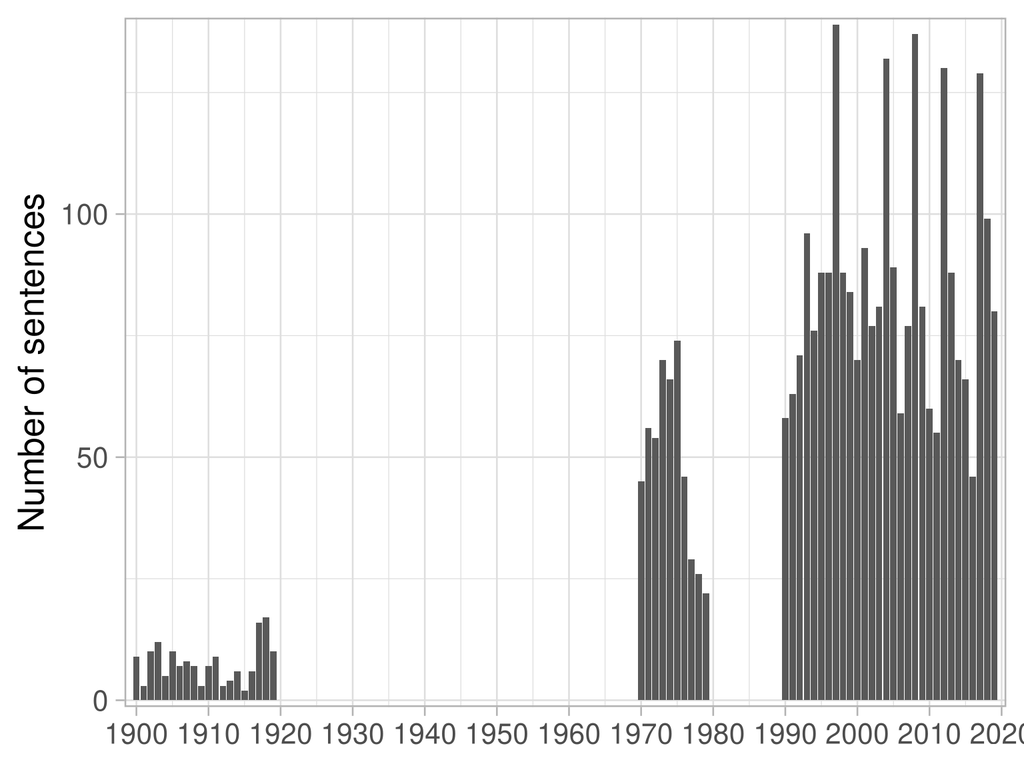

### Closest sentence from ‘rational’ and ‘rationality’ of the backbone community

| Sentence | Title | Year | Journal | Authors | Words Similarity |
| --- | --- | --- | --- | --- | --- |
| Introduction In Political Economy, all actors are assumed to behave rationally, i.e. | [Random Errors, Dirty Information, and Politics](http://www.jstor.org/stable/30027073) | 1996 | Public Choice | Reiner Eichenberger, Angel Serna | 0.804 |
| In section III, we describe the conditions for a rational expectations political/economic equilibrium. | [Partisanship Theory, Macroeconomic Outcomes, and Endogenous Elections](http://www.jstor.org/stable/1060323) | 1991 | Southern Economic Journal | Nathan S. Balke | 0.778 |
| Political rationality It is hard to understate the impact that rational expectations has had on the literature we survey here. | [Political Business Cycles and Macroeconomic Credibility: A Survey](http://www.jstor.org/stable/30024270) | 1997 | Public Choice | Simon Price | 0.774 |
| An experiment in rationality* ANDRE BLAIS1 & ROBERT YOUNG2 1Ddpartement de Science Politique, Universitj de Montreal, C.P. | [Why Do People Vote? An Experiment in Rationality](http://www.jstor.org/stable/30024507) | 1999 | Public Choice | André Blais , Robert Young | 0.768 |
| Political economy not only recognizes but exaggerates individual rationality, assuming an almost ideal efficiency in it, while at the same time the correlative phenomenon of collective rationality is … | [Political Economy and Social Process](http://www.jstor.org/stable/1822590) | 1918 | Journal of Political Economy | Charles H. Cooley | 0.765 |
| If irrationality is treated as a good like any other, then basic price theory implies that deviations from rational expectations are especially likely to surface in political games. | [Rational Irrationality and the Microfoundations of Political Failure](http://www.jstor.org/stable/30026205) | 2001 | Public Choice | Bryan Caplan | 0.765 |
| Given the general acceptance among behavioral economists that the irrationalities in market decisions justify government attempts to improve the rationality of those decisions, it would seem reasonabl… | [Can behavioral economists improve economic rationality?](http://www.jstor.org/stable/48720031) | 2018 | Public Choice | Dwight R. Lee, J. R. Clark | 0.764 |
| This result contributes to the debate abut the effect of rational-choice models on real political behavior. | [Why Do People Vote? An Experiment in Rationality](http://www.jstor.org/stable/30024507) | 1999 | Public Choice | André Blais , Robert Young | 0.760 |
| In this model, it is assumed that individuals are “bounded rational” in the sense that they do not take account of the indirect effect of their lobbying effort on the absolute amount of the total “pie… | [The Effect of Number and Size of Interest Groups on Social Rent Dissipation](http://www.jstor.org/stable/30026125) | 1999 | Public Choice | Guang-Zhen Sun, Yew-Kwang Ng | 0.760 |
| We arrive at one the most important concepts of modern economics if we not only require individual rationality but also coalitional rationality. | [JOHN VON NEUMANN’S CONTRIBUTION TO MODERN GAME THEORY](http://www.jstor.org/stable/90002528) | 2004 | Acta Oeconomica | F. FORGÓ | 0.760 |
| In relatively nonexperimental fields such as political science, the opposition to the use of the “rational choice” approach is based in part on doubts about the extreme rationality assumptions that un… | [The Logit Equilibrium: A Perspective on Intuitive Behavioral Anomalies](http://www.jstor.org/stable/1061555) | 2002 | Southern Economic Journal | Simon P. Anderson, Jacob K. Goeree , Charles A. Holt | 0.750 |
| Finally, the rational expectations approach calls upon market participants to possess an ex traordinary capacity to predict the outcome of political processes. | [The Possibilities and Limits of Aggregate Demand Management](http://www.jstor.org/stable/20642309) | 1978 | Eastern Economic Journal | Charles L. Schultze | 0.747 |
| To a mind as rigidly logical as his own it seemed an obvious truism that if political economy was to be studied at all it must concern itself, in the same sense as chemistry and geology were being pur… | [The Work and Influence of Ricardo](http://www.jstor.org/stable/1814915) | 1911 | The American Economic Review | Jacob H. Hollander | 0.743 |
| Our analysis suggests that expectations of inflation are formed in a rational manner and that voters can therefore be expected to perceive such consequences. | [Granger Causality, Rational Expectations and Aversion to Unemployment and Inflation](http://www.jstor.org/stable/30026901) | 1994 | Public Choice | John Hudson | 0.740 |
| Methodologically, we extend the test of the rational versus the political model. | [Land Tenure Choice in Chinese Villages: The Rational versus the Political Model](http://www.jstor.org/stable/3655804) | 2004 | Land Economics | Yang Yao | 0.740 |
| Springer Science -f Business Media B.V. 2007 Abstract Economists assume that individuals think about the economy like economists, which is especially important in all rational expectations and economi… | [Nonexpert Beliefs about the Macroeconomic Consequences of Economic and Noneconomic Events](http://www.jstor.org/stable/27698146) | 2007 | Public Choice | Michael W. M. Roos | 0.736 |
| It analyzes political behavior and institutions in light of the economic assumption that humans are selfinterested rational actors who respond to incentives. | [GEORGE ORWELL AS A PUBLIC CHOICE ECONOMIST](http://www.jstor.org/stable/43664863) | 2015 | The American Economist | Michael Makovi | 0.735 |
| In general, the presence of rational expectations prevents systematic economic manipulation or political profit by the incumbent because this sort of exploitation would be « seen through » by voters a… | [The Electoral Cycle : a Brief Survey of Literature / Le cycle électoral : une revue brève de la littérature](http://www.jstor.org/stable/24700414) | 1994 | Revue d’économie politique | Gerasimos T. Soldatos | 0.734 |
| The concept of rationality that is employed fails to recognize that-particularly from an economic point of view-political actions only deserve the term “rational” when they include in their search for… | [Institutions and Agricultural Economics](http://www.jstor.org/stable/4226722) | 1993 | Journal of Economic Issues | Konrad Hagedorn | 0.732 |
| When all agents are rational, on the other hand, it is necessary that the uninformed voters cannot simply ‘solve the model’ to get the outcomes. | [Knowledge is Power: A Theory of Information, Income and Welfare Spending](http://www.jstor.org/stable/26746555) | 2017 | Economica | Jo Thori Lind , Dominic Rohner | 0.731 |

### Closest sentences of the backbone community’s centroid

| Sentence | Title | Year | Journal | Authors | Centroid Similarity |
| --- | --- | --- | --- | --- | --- |
| THE JOURNAL OF POLITICAL ECONOMY 7UNE- 1906 THE DEMAND AND SUPPLY CONCEPTS: AN INTRODUCTION TO THE STUDY OF MARKET PRICE The present work has, been undertaken in the belief that the existing status of… | [The Demand and Supply Concepts: An Introduction to the Study of Market Price](http://www.jstor.org/stable/1819697) | 1906 | Journal of Political Economy | Robert H. Hoxie | 0.7810956 |
| It is impossible to do justice to Pantaleoni’s long and complex essay here, but a brief description can be presented in a manner that is sufficient for my purposes.2 Consider a society in which politi… | [Custom, Legislation and Market Order](http://www.jstor.org/stable/3487801) | 2002 | The American Journal of Economics and Sociology | Richard E. Wagner | 0.7499397 |
| A similar formal argument may be advanced against Pantaleoni’s argument about the two pricing systems, one related to the market, the other to the political system. | [Reflections and Diffractions: Schlicht Replies to His Critics](http://www.jstor.org/stable/3487802) | 2002 | The American Journal of Economics and Sociology | Ekkehart Schlicht | 0.7424168 |
| Intrinsic considerations are 10,000 times more important at the ballot box than in the marketplace!7 The immediately foregoing argument I take to be a simple exercise in relative price logic?though th… | [Psychological Dimensions in Voter Choice](http://www.jstor.org/stable/27698312) | 2008 | Public Choice | Geoffrey Brennan | 0.7419078 |
| We have in mind the emphasis upon long-run cost price, the choice of a labour measure of value, the rationale given 1 ‘Senior on Political Economy’, Edinburgh Review, No. | [The Reception of Ricardian Economics](http://www.jstor.org/stable/2662659) | 1977 | Oxford Economic Papers | Samuel Hollander | 0.7344649 |
| A system of political pricing can exist only so long as it remains attracted to a system of market pricing. | [Custom, Legislation and Market Order](http://www.jstor.org/stable/3487801) | 2002 | The American Journal of Economics and Sociology | Richard E. Wagner | 0.7297299 |
| The aim was to critically examine the analogy between price signals on markets for private goods, and what price signals can achieve on a political theory market. | [Rational Ignorance is not Bliss: When do Lazy Voters Learn from Decentralised Policy Experiments?](http://www.jstor.org/stable/23812528) | 2008 | Jahrbücher für Nationalökonomie und Statistik / Journal of Economics and Statistics | Jan Schnellenbach | 0.7291332 |
| Considerations of a political nature may enter to modify economic conclusions. | [Economics and Commercial Education](http://www.jstor.org/stable/2957411) | 1901 | The Economic Journal | L. L. Price | 0.7278389 |
| This study will illustrate the fact which is often overlooked by economists that quite reasonable, if not optimal, adjustments to the economic realities of public choice situations are often possible … | [An Experiment in Public Choice: The Miami Conservancy District, 1913-1922](http://www.jstor.org/stable/30022759) | 1974 | Public Choice | J. Fred Giertz | 0.7277361 |
| To escape error, we ought, in applying the conclusions of political economy to the actual affairs of life, to consider not only what will happen supposing the maximum of competition, but how far the r… | [Comte, Mill, and Cairnes: The Positivist-Empiricist Interlude in Late Classical Economics](http://www.jstor.org/stable/4224239) | 1973 | Journal of Economic Issues | Robert B. Ekelund, Jr., Emilie S. Olsen | 0.7267004 |
| The Nash equilibrium is imported into the political realm from the world of perfect competition where people respond to prices rather than to other people and where it is reasonable to assume that eac… | [Assessing the Citizen: Candidate Model](http://www.jstor.org/stable/30026654) | 2005 | Public Choice | Dan Usher | 0.7238902 |
| A price regime yields a more efficient political equilibrium when this factor is less than one. | [Prices versus Quantities: The Political Perspective](http://www.jstor.org/stable/2138872) | 1997 | Journal of Political Economy | Israel Finkelshtain, Yoav Kislev | 0.7214258 |
| That is, an explicit awareness of the political elements inextricably involved in economic change forces the analyst to the recognition that powerful noneconomic constraints bound the dormin of realis… | [On the Possibility of a Political Economics](http://www.jstor.org/stable/4224050) | 1970 | Journal of Economic Issues | Robert L. Heilbroner | 0.7204072 |
| Each of these options, and many other possible options, illustrates the parasitical quality of political pricing: politics maintains some semblance of pricing, for economic calculation is impossible w… | [Municipal corporations, economic calculation, and political pricing: exploring a theoretical antinomy](http://www.jstor.org/stable/41483728) | 2011 | Public Choice | Richard E. Wagner | 0.7202769 |
| For this reason economists must keep in mind that they are dealing with an issue of constitutional politics and not of mere market calcu tion”. | [A NOTE ON ITALIAN ECONOMICS IN THE EARLY NINETEENTH CENTURY FROM RESTORATION TO RISORGIMENTO](http://www.jstor.org/stable/23722130) | 1993 | History of Economic Ideas | Pier Luigi Porta | 0.7183814 |

### Closest sentences of each kmean cluster’s centroid composing the backbone community

#### Top terms 14_11: political_economy, economy_vol, classical_political, logical_method, cairnes (1900-1919)

| Sentence | Title | Year | Journal | Authors | Distance to Centroid |
| --- | --- | --- | --- | --- | --- |
| of the Theory of Political Economy; pp. | [The Role of Money in Economic Theory](http://www.jstor.org/stable/1803798) | 1916 | The American Economic Review | Wesley C. Mitchell | 6.328189 |
| Thus I Theory of Political Economy, p. i8. | [Some Problems of Logical Method in Political Economy](http://www.jstor.org/stable/1819612) | 1917 | Journal of Political Economy | J. Viner | 6.392988 |
| AN EMINENT ECONOMIST CONFUSED THE writer of this note has recently had called to his attention Professor Carver’s new and interesting Principles of Political Economy. | [An Eminent Economist Confused](http://www.jstor.org/stable/1885952) | 1919 | The Quarterly Journal of Economics | H. G. Brown | 6.505417 |
| When Fisher has carried it out to its logical perfection and has I Stanulaue Co. v. San Joaquwn and K. Rvver Canal and 1rrzatzon Co., 192 U. S. 201, QUARTERLY JOURNAL OF ECONOMICS boldly accepted all … | [Political Economy and Business Economy: Comments on Fisher’s Capital and Income](http://www.jstor.org/stable/1883354) | 1907 | The Quarterly Journal of Economics | NULL | 6.689874 |
| THE JOURNAL OF POLITICAL ECONOMY VOLUME 24 A45ril / 9 1 6 NUMBER 4 FETTER’S “ECONOMIC PRINCIPLES”’ Nothing from Professor Fetter’s pen can fail to claim the attention of all economists interested in t… | [Fetter’s “Economic Principles”](http://www.jstor.org/stable/1820036) | 1916 | Journal of Political Economy | H. J. Davenport | 6.694445 |

#### Top terms 14_90: voting, voter, voters, political_process, vote (1970-1979)

| Sentence | Title | Year | Journal | Authors | Distance to Centroid |
| --- | --- | --- | --- | --- | --- |
| ON THE POSSIBILITY OF A POLITICAL ECONOMICS Robert L. Heilbroner This essay is prompted by a profound sense of dissatisfaction with the state of contemporary economics, a dissatisfaction that finds it… | [On the Possibility of a Political Economics](http://www.jstor.org/stable/4224050) | 1970 | Journal of Economic Issues | Robert L. Heilbroner | 6.656331 |
| Hence my call for a “political economics”, the nature of which I shall try to clarify as a second main purpose of this essay. | [On the Possibility of a Political Economics](http://www.jstor.org/stable/4224050) | 1970 | Journal of Economic Issues | Robert L. Heilbroner | 6.878917 |
| William Stanley Jevons has long been recognized as one of the most original thinkers who have contributed to the development of economic science, and the Theory of Political Economy which he published… | [Jevons, Bentham and De Morgan](http://www.jstor.org/stable/2552637) | 1972 | Economica | R. D. Collison Black | 7.050044 |
| It has long been an established tenet of political economy that politics and economics are not two separate realms, but are, in fact, so closely related that only a relatively limited number of config… | [Alienation, Freedom, and Economic Organization](http://www.jstor.org/stable/1830274) | 1971 | Journal of Political Economy | Edwin G. Dolan | 7.095446 |
| “I deal with the role of”hybris” in economic policy in a paper forthcoming in the Political Science Quarterly. | [Prospective Population Changes and Price Level Tendencies](http://www.jstor.org/stable/1056501) | 1972 | Southern Economic Journal | Joseph J. Spengler | 7.168985 |

#### Top terms 14_123: voters, voter, voting, public_choice, vote (1990-1999)

| Sentence | Title | Year | Journal | Authors | Distance to Centroid |
| --- | --- | --- | --- | --- | --- |
| This work comes against a backdrop of rational choice literature de-emphasizing the importance of legislators’ policy * For financial assistance in conducting this research, we wish to express appreci… | [Policy Views, Constituency Pressure, and Congressional Action on Flag Burning](http://www.jstor.org/stable/30025697) | 1993 | Public Choice | Edward L. Lascher Jr., Steven Kelman , Thomas J. Kane | 6.465688 |
| Presenting this paper at a conference on “Economic Theories of Politics,” Aumann proposed to maintain the basic rationality assumption, but to abandon common knowledge. | [The Impact of Economics on Contemporary Political Science](http://www.jstor.org/stable/2729975) | 1997 | Journal of Economic Literature | Gary J. Miller | 6.783737 |
| During the years 1950-70, political scientists were either indifferent to or hostile to the emerging field of rational choice in which the approach and tools of economics are applied to politics. | [Political Science and Public Choice: 1950-70](http://www.jstor.org/stable/30024485) | 1999 | Public Choice | William C. Mitchell | 6.788600 |
| When one looks at what seems to be happening in political science from the outside perspective of an economist, one is reminded of the methodological revolutions that took place in economics over the … | [The Future of Public Choice](http://www.jstor.org/stable/30027214) | 1993 | Public Choice | Dennis C. Mueller | 7.038868 |
| Market rationality forces its way into the political processes. | [The World Market Unbound](http://www.jstor.org/stable/4177234) | 1997 | Review of International Political Economy | Elmar Altvater , Birgit Mahnkopf, Alan Scott | 7.080199 |

#### Top terms 14_136: voting, voters, voter, vote, public_choice (2000-2009)

| Sentence | Title | Year | Journal | Authors | Distance to Centroid |
| --- | --- | --- | --- | --- | --- |
| Introduction and Overview Much of political philosophy and public choice theory share a common model of rational individual behavior. | [Public Choice and Political Philosophy: Reflections on the Works of Gordon Spinoza and David Immanuel Buchanan](http://www.jstor.org/stable/30026661) | 2005 | Public Choice | Hartmut Kliemt | 6.908441 |
| In relatively nonexperimental fields such as political science, the opposition to the use of the “rational choice” approach is based in part on doubts about the extreme rationality assumptions that un… | [The Logit Equilibrium: A Perspective on Intuitive Behavioral Anomalies](http://www.jstor.org/stable/1061555) | 2002 | Southern Economic Journal | Simon P. Anderson, Jacob K. Goeree , Charles A. Holt | 7.026576 |
| 1990 Political science and rational choice. | [The Contributions and Impact of Professor William H. Riker](http://www.jstor.org/stable/30025894) | 2003 | Public Choice | Kellie Maske, Garey Durden | 7.131367 |
| The modelling in this paper makes this presumption explicit and shows that if the benefit of voting depends on expectations as to 4. | [Bandwagons and Momentum in Sequential Voting](http://www.jstor.org/stable/4626156) | 2007 | The Review of Economic Studies | Steven Callander | 7.244507 |
| 5 Summary In this paper, I have advanced what I regard as the “truly rational” account of voting behav iour. | [Psychological Dimensions in Voter Choice](http://www.jstor.org/stable/27698312) | 2008 | Public Choice | Geoffrey Brennan | 7.250377 |

#### Top terms 14_151: voters, voting, voter, rational_voter, vote (2010-2019)

| Sentence | Title | Year | Journal | Authors | Distance to Centroid |
| --- | --- | --- | --- | --- | --- |
| Kaplow and Kominers argue in this issue that this makes the purely rational analysis of QV in LW and in the preceding subsection of this paper largely irrelevant to the likely outcomes that would aris… | [The robustness of quadratic voting](http://www.jstor.org/stable/48719871) | 2017 | Public Choice | E. Glen Weyl | 6.825740 |
| When we require the strategies to constitute a Nash equilibrium and there is a positive probability of being pivotal, a rational voter might not behave like the sincere voter. | [Ideologues Beat Idealists](http://www.jstor.org/stable/23249432) | 2012 | American Economic Journal: Microeconomics | Sambuddha Ghosh , Vinayak Tripathi | 6.934819 |
| First, while existing work focuses on sincere voting, we consider fully rational voters who vote strategically.5 Second, we introduce uncertainty regarding others’ preferences. | [COMBINATORIAL VOTING](http://www.jstor.org/stable/41336582) | 2012 | Econometrica | David S. Ahn , Santiago Oliveros | 7.003094 |
| We investigate voters’ behavior when this tradeoff is present, and when voters’ decisions are not trivial. | [Condemning corruption while condoning inefficiency](http://www.jstor.org/stable/48719992) | 2017 | Public Choice | Paulo Arvate , Sergio Mittlaender | 7.012038 |
| We abstract from every other aspect that may influence voting decisions and derive a prototypical rational-choice, decision theoretic model of voting. | [Referendum design, quorum rules and turnout](http://www.jstor.org/stable/40661049) | 2010 | Public Choice | Luís Aguiar-Conraria, Pedro C. Magalhães | 7.168914 |

### Top articles (most sentences) of the backbone cluster

| Title | Year | Journal | Authors | Number sentences | Words Similarity |
| --- | --- | --- | --- | --- | --- |
| [Collective decision-making of voters with heterogeneous levels of rationality](http://www.jstor.org/stable/48703355) | 2019 | Public Choice | Youzong Xu | 30 | 0.629 |
| [The Impact of Economics on Contemporary Political Science](http://www.jstor.org/stable/2729975) | 1997 | Journal of Economic Literature | Gary J. Miller | 22 | 0.627 |
| [The Political Economy of Dynamic Elections: Accountability, Commitment, and Responsiveness](http://www.jstor.org/stable/26303308) | 2017 | Journal of Economic Literature | John Duggan , César Martinelli | 17 | 0.596 |
| [Who will vote quadratically? Voter turnout and votes cast under quadratic voting](http://www.jstor.org/stable/48719873) | 2017 | Public Choice | Louis Kaplow , Scott Duke Kominers | 16 | 0.633 |
| [Impressionable Voters](http://www.jstor.org/stable/26641403) | 2019 | American Economic Journal: Microeconomics | Costel Andonie , Daniel Diermeier | 16 | 0.622 |
| [Correlation Neglect, Voting Behavior, and Information Aggregation](http://www.jstor.org/stable/43495430) | 2015 | The American Economic Review | Gilat Levy , Ronny Razin | 15 | 0.607 |
| [Rational Irrationality and the Microfoundations of Political Failure](http://www.jstor.org/stable/30026205) | 2001 | Public Choice | Bryan Caplan | 14 | 0.653 |
| [Psychological Dimensions in Voter Choice](http://www.jstor.org/stable/27698312) | 2008 | Public Choice | Geoffrey Brennan | 14 | 0.623 |
| [Economics: Allocation or Valuation?](http://www.jstor.org/stable/4224360) | 1974 | Journal of Economic Issues | Philip A. Klein | 12 | 0.612 |
| [Political Business Cycles and Macroeconomic Credibility: A Survey](http://www.jstor.org/stable/30024270) | 1997 | Public Choice | Simon Price | 12 | 0.635 |
| [Expressive Voting and Electoral Equilibrium](http://www.jstor.org/stable/30024365) | 1998 | Public Choice | Geoffrey Brennan, Alan Hamlin | 12 | 0.619 |
| [Some Problems of Logical Method in Political Economy](http://www.jstor.org/stable/1819612) | 1917 | Journal of Political Economy | J. Viner | 11 | 0.629 |
| [Rational Ignorance, Rational Voter Expectations, and Public Policy: A Discrete Informational Foundation for Fiscal Illusion](http://www.jstor.org/stable/30026254) | 2001 | Public Choice | Roger D. Congleton | 11 | 0.632 |
| [The Survival of the Welfare State](http://www.jstor.org/stable/3132163) | 2003 | The American Economic Review | John Hassler , José V. Rodríguez Mora, Kjetil Storesletten , Fabrizio Zilibotti | 11 | 0.610 |
| [A Clear Test of Rational Voting](http://www.jstor.org/stable/30022827) | 1975 | Public Choice | Jeffrey W. Smith | 10 | 0.629 |

### Top articles (most sentences) of the cluster for each time window

#### Top articles for 14_11: political_economy, economy_vol, classical_political, logical_method, cairnes (1900-1919)

| Title | Year | Journal | Authors | Number sentences | Words Similarity |
| --- | --- | --- | --- | --- | --- |
| [Some Problems of Logical Method in Political Economy](http://www.jstor.org/stable/1819612) | 1917 | Journal of Political Economy | J. Viner | 11 | 0.629 |
| [Modern Logicians and Economic Methods](http://www.jstor.org/stable/2221171) | 1905 | The Economic Journal | R. B. Haldane | 6 | 0.631 |
| [The Present Position of Political Economy](http://www.jstor.org/stable/2220849) | 1907 | The Economic Journal | W. J. Ashley | 5 | 0.626 |
| [The Preconceptions of Economic Science](http://www.jstor.org/stable/1883770) | 1900 | The Quarterly Journal of Economics | Thorstein Veblen | 4 | 0.666 |
| [Nassau W. Senior, British Economist, in the Light of Recent Researches: II](http://www.jstor.org/stable/1822413) | 1918 | Journal of Political Economy | S. Leon Levy | 4 | 0.619 |
| [A Parallel Between Economic and Political Theory](http://www.jstor.org/stable/2957298) | 1902 | The Economic Journal | A. C. Pigou | 3 | 0.644 |
| [The Study of Comparative Legislation](http://www.jstor.org/stable/1820463) | 1903 | Journal of Political Economy | Max West | 3 | 0.637 |
| [The Enlargement of Economics](http://www.jstor.org/stable/2220699) | 1908 | The Economic Journal | W. J. Ashley | 3 | 0.627 |
| [The Work and Influence of Ricardo](http://www.jstor.org/stable/1814915) | 1911 | The American Economic Review | Jacob H. Hollander | 3 | 0.640 |
| [Jevons’ “Theory of Political Economy.”](http://www.jstor.org/stable/1804593) | 1912 | The American Economic Review | Allyn A. Young | 3 | 0.644 |

#### Top articles for 14_90: voting, voter, voters, political_process, vote (1970-1979)

| Title | Year | Journal | Authors | Number sentences | Words Similarity |
| --- | --- | --- | --- | --- | --- |
| [Economics: Allocation or Valuation?](http://www.jstor.org/stable/4224360) | 1974 | Journal of Economic Issues | Philip A. Klein | 12 | 0.612 |
| [A Clear Test of Rational Voting](http://www.jstor.org/stable/30022827) | 1975 | Public Choice | Jeffrey W. Smith | 10 | 0.629 |
| [On the Possibility of a Political Economics](http://www.jstor.org/stable/4224050) | 1970 | Journal of Economic Issues | Robert L. Heilbroner | 9 | 0.625 |
| [Normative Assumptions in the Study of Public Choice](http://www.jstor.org/stable/30022733) | 1973 | Public Choice | Duncan MacRae Jr. | 7 | 0.603 |
| [The Calculus of Rational Choice](http://www.jstor.org/stable/30022751) | 1974 | Public Choice | William C. Stratmann | 7 | 0.640 |
| [Synoptic versus Incremental Scholarly Advice in Economic Policy: Some Implications of So-Called “Rational” Tax Systems](http://www.jstor.org/stable/40910769) | 1970 | FinanzArchiv / Public Finance Analysis | Gunther Engelhardt | 6 | 0.630 |
| [Malthus and Ricardo’s Inductivist Critics: Four Letters to William Whewell](http://www.jstor.org/stable/2553320) | 1973 | Economica | N. B. de Marchi, R. P. Sturges | 6 | 0.599 |
| [The Properties and Relevancy of Merit Goods](http://www.jstor.org/stable/40910860) | 1971 | FinanzArchiv / Public Finance Analysis | Allan G. Pulsipher | 5 | 0.605 |
| [Constitutional Democracy and Social Welfare](http://www.jstor.org/stable/1885224) | 1973 | The Quarterly Journal of Economics | Dennis C. Mueller | 4 | 0.608 |
| [Flexibility and Consistency in Project Evaluation](http://www.jstor.org/stable/2553426) | 1974 | Economica | E. J. Mishan | 4 | 0.611 |

#### Top articles for 14_123: voters, voter, voting, public_choice, vote (1990-1999)

| Title | Year | Journal | Authors | Number sentences | Words Similarity |
| --- | --- | --- | --- | --- | --- |
| [The Impact of Economics on Contemporary Political Science](http://www.jstor.org/stable/2729975) | 1997 | Journal of Economic Literature | Gary J. Miller | 22 | 0.627 |
| [Political Business Cycles and Macroeconomic Credibility: A Survey](http://www.jstor.org/stable/30024270) | 1997 | Public Choice | Simon Price | 12 | 0.635 |
| [Expressive Voting and Electoral Equilibrium](http://www.jstor.org/stable/30024365) | 1998 | Public Choice | Geoffrey Brennan, Alan Hamlin | 12 | 0.619 |
| [Institutions and Agricultural Economics](http://www.jstor.org/stable/4226722) | 1993 | Journal of Economic Issues | Konrad Hagedorn | 10 | 0.618 |
| [Why Do People Vote? An Experiment in Rationality](http://www.jstor.org/stable/30024507) | 1999 | Public Choice | André Blais , Robert Young | 10 | 0.654 |
| [The New Political Macroeconomics: An Interview with Alberto Alesina](http://www.jstor.org/stable/25604153) | 1999 | The American Economist | Brian Snowdon , Howard R. Vane , Alberto Alesina | 9 | 0.637 |
| [Partisanship Theory, Macroeconomic Outcomes, and Endogenous Elections](http://www.jstor.org/stable/1060323) | 1991 | Southern Economic Journal | Nathan S. Balke | 7 | 0.644 |
| [Competition in Political and Economic Markets](http://www.jstor.org/stable/30025445) | 1991 | Public Choice | Don L. Coursey , Russell D. Roberts | 7 | 0.616 |
| [Rationality and the Political Business Cycle: The Case of Local Government](http://www.jstor.org/stable/30025727) | 1992 | Public Choice | Jacob Rosenberg | 6 | 0.631 |
| [Strategic Voting under Proportional Representation](http://www.jstor.org/stable/765114) | 1996 | Journal of Law, Economics, & Organization | Gary W. Cox , Matthew Soberg Shugart | 6 | 0.653 |

#### Top articles for 14_136: voting, voters, voter, vote, public_choice (2000-2009)

| Title | Year | Journal | Authors | Number sentences | Words Similarity |
| --- | --- | --- | --- | --- | --- |
| [Rational Irrationality and the Microfoundations of Political Failure](http://www.jstor.org/stable/30026205) | 2001 | Public Choice | Bryan Caplan | 14 | 0.653 |
| [Psychological Dimensions in Voter Choice](http://www.jstor.org/stable/27698312) | 2008 | Public Choice | Geoffrey Brennan | 14 | 0.623 |
| [Rational Ignorance, Rational Voter Expectations, and Public Policy: A Discrete Informational Foundation for Fiscal Illusion](http://www.jstor.org/stable/30026254) | 2001 | Public Choice | Roger D. Congleton | 11 | 0.632 |
| [The Survival of the Welfare State](http://www.jstor.org/stable/3132163) | 2003 | The American Economic Review | John Hassler , José V. Rodríguez Mora, Kjetil Storesletten , Fabrizio Zilibotti | 11 | 0.610 |
| [Political Coase Theorem](http://www.jstor.org/stable/30025972) | 2003 | Public Choice | Francesco Parisi | 10 | 0.609 |
| [Public Choice Economics: Where Is There Consensus?](http://www.jstor.org/stable/25604314) | 2005 | The American Economist | Robert Whaples , Jac C. Heckelman | 9 | 0.656 |
| [Is Internet Voting a Good Thing?](http://www.jstor.org/stable/40752230) | 2000 | Journal of Institutional and Theoretical Economics (JITE) / Zeitschrift für die gesamte Staatswissenschaft | Tilman Börgers | 8 | 0.622 |
| [The Contributions and Impact of Professor William H. Riker](http://www.jstor.org/stable/30025894) | 2003 | Public Choice | Kellie Maske, Garey Durden | 8 | 0.623 |
| [Pocketbook Predictions of Presidential Elections: POCKETBOOK VARIABLES ARE ALMOST ALWAYS GOOD INDICATORS OF ELECTORAL OUTCOMES](http://www.jstor.org/stable/23490124) | 2004 | Business Economics | Patrick L. Anderson , Ilhan Kubilay Geckil | 8 | 0.624 |
| [THE POLITICAL BUSINESS CYCLE AT SIXTY: TOWARDS A NEO-KALECKIAN UNDERSTANDING OF POLITICAL ECONOMY?](http://www.jstor.org/stable/43107599) | 2004 | Cahiers d’économie politique / Papers in Political Economy | Jan-Peter Olters | 7 | 0.610 |

#### Top articles for 14_151: voters, voting, voter, rational_voter, vote (2010-2019)

| Title | Year | Journal | Authors | Number sentences | Words Similarity |
| --- | --- | --- | --- | --- | --- |
| [Collective decision-making of voters with heterogeneous levels of rationality](http://www.jstor.org/stable/48703355) | 2019 | Public Choice | Youzong Xu | 30 | 0.629 |
| [The Political Economy of Dynamic Elections: Accountability, Commitment, and Responsiveness](http://www.jstor.org/stable/26303308) | 2017 | Journal of Economic Literature | John Duggan , César Martinelli | 17 | 0.596 |
| [Who will vote quadratically? Voter turnout and votes cast under quadratic voting](http://www.jstor.org/stable/48719873) | 2017 | Public Choice | Louis Kaplow , Scott Duke Kominers | 16 | 0.633 |
| [Impressionable Voters](http://www.jstor.org/stable/26641403) | 2019 | American Economic Journal: Microeconomics | Costel Andonie , Daniel Diermeier | 16 | 0.622 |
| [Correlation Neglect, Voting Behavior, and Information Aggregation](http://www.jstor.org/stable/43495430) | 2015 | The American Economic Review | Gilat Levy , Ronny Razin | 15 | 0.607 |
| [Ideologues Beat Idealists](http://www.jstor.org/stable/23249432) | 2012 | American Economic Journal: Microeconomics | Sambuddha Ghosh , Vinayak Tripathi | 10 | 0.633 |
| [Public choice and political science](http://www.jstor.org/stable/48719897) | 2018 | Public Choice | Peter Kurrild-Klitgaard | 9 | 0.614 |
| [Can Words Get in the Way? The Effect of Deliberation in Collective Decision Making](http://www.jstor.org/stable/26550387) | 2018 | Journal of Political Economy | Matias Iaryczower, Xiaoxia Shi , Matthew Shum | 8 | 0.606 |
| [The Demand for Bad Policy when Voters Underappreciate Equilibrium Effects](http://www.jstor.org/stable/26543908) | 2018 | The Review of Economic Studies | ERNESTO DAL BÓ, PEDRO DAL BÓ , ERIK EYSTER | 7 | 0.600 |
| [RETROSPECTIVE VOTING AND PARTY POLARIZATION](http://www.jstor.org/stable/45117639) | 2019 | International Economic Review | Ignacio Esponda, Demian Pouzo | 7 | 0.623 |

### Most cited references in the backbone community

| First Author | Year | Journal | Citation by article | Citation by sentence |
| --- | --- | --- | --- | --- |
| COASE-R | 1960 | J LAW EC | 3 | 75 |
| BESLEY-T | 1997 | Q J ECON | 24 | 72 |
| HOTELLING-H | 1929 | EC J | 2 | 64 |
| FERNANDEZ-R | 1991 | AM ECON REV | 2 | 48 |
| BARR-J | 1966 | SO EC J | 8 | 32 |
| GROSSMAN-G | 1994 | AM ECON REV | 16 | 16 |
| PELTZMAN-S | 1976 | J LAW EC | 14 | 14 |
| ROGOFF-K | 1988 | REV EC STUDIES | 12 | 12 |
| ROGOFF-K | 1990 | AM ECON REV | 11 | 11 |
| NORDHAUS-W | 1975 | REV EC STUDIES | 5 | 10 |
| TIEBOUT-C | 1956 | J POLIT EC | 3 | 9 |
| BERGSTROM-T | 1973 | AM EC REV | 2 | 6 |
| RIKER-W | 1968 | AM POLITICAL SCI REV | 2 | 6 |
| KNIGHT-F | 1924 | Q J EC | 2 | 6 |
| BATOR-F | 1958 | Q J EC | 2 | 6 |

| First Author | Year | Journal | Citation by article | Citation by sentence |
| --- | --- | --- | --- | --- |
| DOWNS-A | 1957 | EC THEORY DEMOCRACY | 195 | 8970 |
| OLSON-M | 1965 | LOGIC COLLECTIVE ACT | 70 | 2520 |
| MUELLER-D | 1989 | PUBLIC CHOICE | 59 | 1534 |
| BUCHANAN-J | 1962 | CALCULUS CONSENT LOG | 80 | 1520 |
| NISKANEN-W | 1971 | BUREAUCRACY REPRESEN | 20 | 440 |
| NORTH-D | 1990 | I I CHANGE EC PERFOR | 16 | 352 |
| NORTH-D | 1981 | STRUCTURE CHANGE EC | 12 | 264 |
| BRENNAN-G | 1993 | DEMOCRACY DECISION | 18 | 252 |
| PERSSON-T | 2000 | POLITICAL EC EXPLAIN | 30 | 180 |
| ARROW-K | 1963 | SOCIAL CHOICE INDIVI | 10 | 120 |
| FRIEDMAN-M | 1962 | CAPITALISM FREEDOM | 7 | 84 |
| DOWNS-A | 1957 | ECONOMIC THEORY DEMO | 27 | 81 |
| GALBRAITH-J | 1967 | NEW INDUSTRIAL STATE | 4 | 48 |
| GRUCHY-A | 1972 | CONTEMPORARY ECONOMI | 4 | 48 |
| NORDHAUS-W | 1972 | 50TH ANNIVERSARY COL | 4 | 48 |

### Most cited references per kmean clusters

#### Top references 14_90: voting, voter, voters, political_process, vote (1970-1979)

| First Author | Year | Journal | Citation by article | Citation by sentence |
| --- | --- | --- | --- | --- |
| GURLEY-J | 1972 | AM ECONOMIC REV | 1 | 12 |
| TIEBOUT-C | 1956 | J POLIT EC | 3 | 9 |
| SLOBODKIN-L | 1965 | AM SCIENTIST SEP | 1 | 9 |
| BOULDING-K | 1966 | MAY P AM EC ASSOC | 1 | 9 |
| LOWE-A | 1965 | ECONOMIC KNOWLEDGE | 1 | 9 |
| ROPER-E | 1959 | SATURDAY REV 0606 | 1 | 9 |
| COASE-R | 1960 | J LAW EC | 2 | 6 |
| BERGSTROM-T | 1973 | AM EC REV | 2 | 6 |
| RIKER-W | 1968 | AM POLITICAL SCI REV | 2 | 6 |
| KNIGHT-F | 1924 | Q J EC | 2 | 6 |

| First Author | Year | Journal | Citation by article | Citation by sentence |
| --- | --- | --- | --- | --- |
| ARROW-K | 1963 | SOCIAL CHOICE INDIVI | 10 | 120 |
| BUCHANAN-J | 1962 | CALCULUS CONSENT LOG | 21 | 84 |
| FRIEDMAN-M | 1962 | CAPITALISM FREEDOM | 7 | 84 |
| DOWNS-A | 1957 | ECONOMIC THEORY DEMO | 27 | 81 |
| GALBRAITH-J | 1967 | NEW INDUSTRIAL STATE | 4 | 48 |
| GRUCHY-A | 1972 | CONTEMPORARY ECONOMI | 4 | 48 |
| NORDHAUS-W | 1972 | 50TH ANNIVERSARY COL | 4 | 48 |

#### Top references 14_123: voters, voter, voting, public_choice, vote (1990-1999)

| First Author | Year | Journal | Citation by article | Citation by sentence |
| --- | --- | --- | --- | --- |
| WEINGAST-B | 1988 | J POLIT ECON | 1 | 22 |
| TRIVERS-R | 1971 | Q REV BIOL | 1 | 22 |
| BIKHCHANDANI-S | 1992 | J POLIT ECON | 1 | 22 |
| COASE-R | 1960 | J LAW EC | 1 | 22 |
| AKERLOF-G | 1970 | Q J EC | 1 | 22 |
| COASE-R | 1937 | ECONOMICA | 1 | 22 |
| PLOTT-C | 1967 | AM EC REV | 1 | 22 |
| WEINGAST-B | 1983 | J POLITICAL EC | 1 | 22 |
| GREIF-A | 1989 | J ECON HIST | 1 | 22 |
| HOLMSTROM-B | 1979 | BELL J EC | 1 | 22 |

| First Author | Year | Journal | Citation by article | Citation by sentence |
| --- | --- | --- | --- | --- |
| DOWNS-A | 1957 | EC THEORY DEMOCRACY | 80 | 1760 |
| OLSON-M | 1965 | LOGIC COLLECTIVE ACT | 48 | 1056 |
| MUELLER-D | 1989 | PUBLIC CHOICE | 40 | 480 |
| NISKANEN-W | 1971 | BUREAUCRACY REPRESEN | 20 | 440 |
| NORTH-D | 1990 | I I CHANGE EC PERFOR | 16 | 352 |
| NORTH-D | 1981 | STRUCTURE CHANGE EC | 12 | 264 |

#### Top references 14_136: voting, voters, voter, vote, public_choice (2000-2009)

| First Author | Year | Journal | Citation by article | Citation by sentence |
| --- | --- | --- | --- | --- |
| GROSSMAN-G | 1994 | AM ECON REV | 16 | 16 |
| BESLEY-T | 1997 | Q J ECON | 16 | 16 |
| BESLEY-T | 1997 | Q J ECON | 8 | 16 |
| PELTZMAN-S | 1976 | J LAW EC | 14 | 14 |
| WITTMAN-D | 1989 | J POLIT ECON | 1 | 14 |
| TOLLISON-R | 1982 | KYKLOS | 1 | 14 |
| TULLOCK-G | 1967 | WESTERN EC J | 1 | 14 |
| BRENNAN-G | 1984 | AM BEHAV SCI | 1 | 14 |
| KELMAN-M | 1988 | VA LAW REV | 1 | 14 |
| SHILLER-R | 1991 | AM ECON REV | 1 | 14 |

| First Author | Year | Journal | Citation by article | Citation by sentence |
| --- | --- | --- | --- | --- |
| DOWNS-A | 1957 | EC THEORY DEMOCRACY | 73 | 1022 |
| BUCHANAN-J | 1962 | CALCULUS CONSENT LOG | 32 | 320 |
| OLSON-M | 1965 | LOGIC COLLECTIVE ACT | 22 | 308 |
| MUELLER-D | 1989 | PUBLIC CHOICE | 19 | 266 |
| BRENNAN-G | 1993 | DEMOCRACY DECISION | 18 | 252 |

#### Top references 14_151: voters, voting, voter, rational_voter, vote (2010-2019)

| First Author | Year | Journal | Citation by article | Citation by sentence |
| --- | --- | --- | --- | --- |
| ROGOFF-K | 1988 | REV EC STUDIES | 12 | 12 |
| ROGOFF-K | 1990 | AM ECON REV | 11 | 11 |
| SAMUELSON-W | 1988 | J RISK UNCERTAINTY | 1 | 10 |
| HOTELLING-H | 1929 | EC J | 1 | 10 |
| SELTEN-R | 1975 | INT J GAME THEORY | 1 | 10 |
| NORDHAUS-W | 1975 | REV EC STUDIES | 5 | 10 |
| HARSANYI-J | 1980 | THEOR DECIS | 1 | 10 |
| FERNANDEZ-R | 1991 | AM ECON REV | 1 | 10 |
| HANSSON-I | 1984 | PUBLIC CHOICE | 1 | 10 |
| STOKES-D | 1963 | AM POLIT SCI REV | 1 | 10 |

| First Author | Year | Journal | Citation by article | Citation by sentence |
| --- | --- | --- | --- | --- |
| DOWNS-A | 1957 | EC THEORY DEMOCRACY | 42 | 420 |
| PERSSON-T | 2000 | POLITICAL EC EXPLAIN | 30 | 180 |
| BUCHANAN-J | 1962 | CALCULUS CONSENT LOG | 27 | 135 |

## Intertemporal cluster *15: farm, agricultural, agriculture, farmers*

The cluster gathers 835 sentences from our corpus. It represents 0.52% of all the sentences selected over the whole period.

The community exists from 1900 to 1969.

The most recurring authors are Harry Gunnison Brown (17 sentences; 10 articles), H. J. Davenport (13 sentences; 9 articles), M. M. Kelso (13 sentences; 4 articles), F. Y. Edgeworth (12 sentences; 5 articles), Frank A. Fetter (12 sentences; 3 articles), Edwin R. A. Seligman (11 sentences; 3 articles), E. G. Nourse (11 sentences; 9 articles), Richard T. Ely (9 sentences; 8 articles), J. Wilczynski (9 sentences; 1 articles), H. C. M. Case (8 sentences; 3 articles), Walter C. Neale (8 sentences; 1 articles).

The most recurring journals are Journal of Farm Economics (316 sentences; 243 articles), Journal of Political Economy (82 sentences; 66 articles), The American Economic Review (82 sentences; 69 articles), The Economic Journal (80 sentences; 52 articles), The Quarterly Journal of Economics (75 sentences; 57 articles).

### Top TF-IDF terms describing the community

| Token | TF-IDF |
| --- | --- |
| farm | 0.0079507 |
| agricultural | 0.0063013 |
| agriculture | 0.0056363 |
| farmers | 0.0053794 |
| farmer | 0.0050542 |
| land | 0.0049525 |
| land_economics | 0.0046066 |
| peasant | 0.0033197 |
| farmer’s | 0.0032374 |
| agricultural_economics | 0.0028762 |
| maximum_profits | 0.0026924 |
| farms | 0.0024929 |
| indian | 0.0024239 |
| farming | 0.0022597 |
| parsons | 0.0020791 |
| wisconsin | 0.0018697 |
| parity | 0.0018268 |
| wage_rates | 0.0018233 |
| personnel | 0.0017343 |
| lands | 0.0016696 |

### Top TF-IDF terms describing the different k-means clusters

#### Top terms 15_12: land, rent, private_property, wheat, taxation (1900-1919)

| Token | TF-IDF |
| --- | --- |
| land | 0.0095134 |
| rent | 0.0053566 |
| private_property | 0.0030590 |
| wheat | 0.0026391 |
| taxation | 0.0025541 |
| farmer | 0.0024835 |
| lands | 0.0023075 |
| fertility | 0.0021681 |
| agricultural | 0.0020342 |
| ricardian_theory | 0.0019925 |
| water | 0.0018117 |
| inducement | 0.0017758 |
| earning | 0.0016427 |
| cultivation | 0.0016261 |
| house | 0.0015810 |

#### Top terms 15_24: land, farm, farmer, agricultural, agriculture (1920-1939)

| Token | TF-IDF |
| --- | --- |
| land | 0.0094966 |
| farm | 0.0077327 |
| farmer | 0.0070832 |
| agricultural | 0.0066306 |
| agriculture | 0.0065816 |
| farmers | 0.0047589 |
| farms | 0.0035256 |
| farming | 0.0025183 |
| wheat | 0.0025090 |
| lands | 0.0023504 |
| malthus | 0.0021473 |
| farmer’s | 0.0020923 |
| cultivation | 0.0017667 |
| manufactures | 0.0016237 |
| rent | 0.0016131 |

#### Top terms 15_47: agriculture, farm, agricultural, land, land_economics (1940-1949)

| Token | TF-IDF |
| --- | --- |
| agriculture | 0.0105870 |
| farm | 0.0087613 |
| agricultural | 0.0086082 |
| land | 0.0067706 |
| land_economics | 0.0061722 |
| farmers | 0.0051351 |
| farmer | 0.0047770 |
| farms | 0.0047554 |
| urban | 0.0037332 |
| parity | 0.0035388 |
| maximum_profits | 0.0028533 |
| conservation | 0.0028134 |
| parsons | 0.0022399 |
| wisconsin | 0.0020305 |
| wage_rates | 0.0019841 |

#### Top terms 15_61: farm, farmers, agricultural, farmer, agriculture (1950-1959)

| Token | TF-IDF |
| --- | --- |
| farm | 0.0163638 |
| farmers | 0.0129944 |
| agricultural | 0.0097599 |
| farmer | 0.0093252 |
| agriculture | 0.0064896 |
| farmer’s | 0.0064271 |
| peasant | 0.0055949 |
| indian | 0.0046624 |
| farming | 0.0041258 |
| corn | 0.0033551 |
| peasants | 0.0024939 |
| farms | 0.0020629 |
| lands | 0.0019253 |
| land | 0.0017861 |
| agricultural_economics | 0.0017570 |

#### Top terms 15_65: farm, agricultural, agricultural_economics, farmers, land (1960-1969)

| Token | TF-IDF |
| --- | --- |
| farm | 0.0115009 |
| agricultural | 0.0094765 |
| agricultural_economics | 0.0076561 |
| farmers | 0.0075835 |
| land | 0.0074585 |
| agriculture | 0.0073415 |
| land_economics | 0.0072920 |
| farmer | 0.0047971 |
| peasant | 0.0045712 |
| farming | 0.0028091 |
| farms | 0.0022473 |
| personnel | 0.0018610 |
| farmer’s | 0.0017504 |
| malthus | 0.0016767 |
| shadow | 0.0016375 |

### Distribution of sentences over time

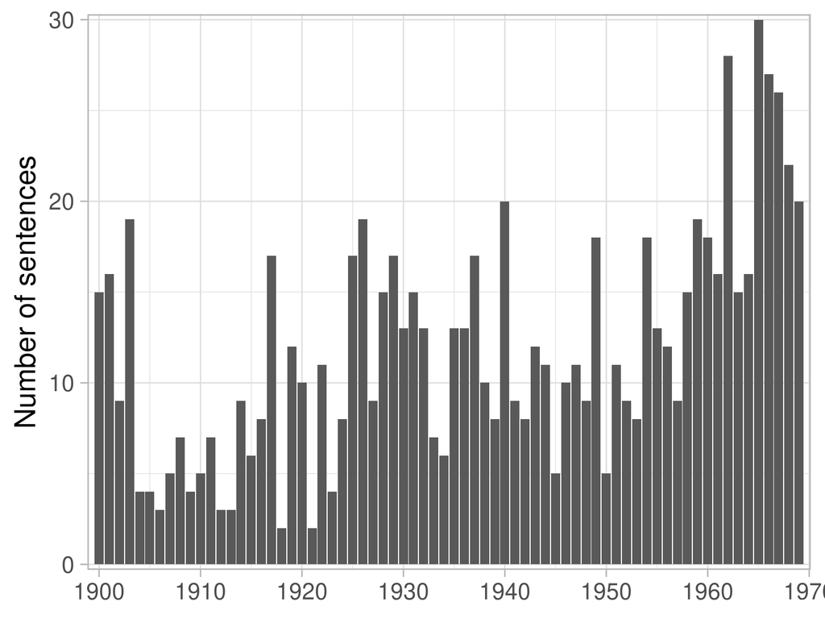

### Closest sentence from ‘rational’ and ‘rationality’ of the backbone community

| Sentence | Title | Year | Journal | Authors | Words Similarity |
| --- | --- | --- | --- | --- | --- |
| Implications If the foregoing analysis is indicative of the general picture, it helps explain the behavior of farmers who might be judged irrational on strict price and cost grounds. | [Farmer’s Choice of Hog Markets](http://www.jstor.org/stable/1233886) | 1957 | Journal of Farm Economics | R. L. Kohls , John Gifford | 0.707 |
| TOWARDS RATIONALITY IN LAND ECONOMICS 559 furthermore, so much depends on the judgment of top planners. | [Towards Rationality in Land Economics under Central Planning](http://www.jstor.org/stable/2230381) | 1969 | The Economic Journal | J. Wilczynski | 0.707 |
| J. Lewandowski states that for a choice to be made between the various methods of increase in production, in accordance with the principles of rational administration, all factors of production, which… | [The Price of Nationalized Land under Socialism](http://www.jstor.org/stable/4379365) | 1968 | Eastern European Economics | Henryk Cholaj | 0.704 |
| This remark does not express a farmer’s prejudice, but a purely rational idea - rational from the point of view of the village as well as of the national economy. | [Agricultural Circles in the Light of the General Problems of Agriculture](http://www.jstor.org/stable/4379327) | 1966 | Eastern European Economics | Jerzy Tepicht | 0.699 |
| This chapter forms the logical outcome of the author’s views with regard to the conception and object of wealth. | [A Bibliographical Discovery in Political Economy](http://www.jstor.org/stable/1819679) | 1901 | Journal of Political Economy | Leopold Katscher | 0.697 |
| It may be granted also that in some branches of current economic activity-say, agricultural production under what amounts to a system of ” peasant proprietors “-it is conceivable that the individual i… | [The Definition of the Concept of a “Velocity of Circulation of Goods” Part I](http://www.jstor.org/stable/2549143) | 1932 | Economica | Arthur W. Marget | 0.696 |
| It should be noted, however, that the acceptance of the claim that farm operators are economically rational and are “efficiently” allocating the resources at their disposal, does not necessarily entai… | [Resource Allocation in Traditional Agriculture: Comment](http://www.jstor.org/stable/1236951) | 1967 | Journal of Farm Economics | Dale W. Adams | 0.694 |
| If the farm-firm problems are defined in a specific manner, then the management process will be more “rational.” | [A Systematic Conceptualization of Farm Management](http://www.jstor.org/stable/1237067) | 1967 | Journal of Farm Economics | Willard T. Rushton, E. T. Shaudys | 0.694 |
| We have become aware that the conventional references to economic behavior are not only incomplete, that the division between land, capital, wages, etc., is not only a scanty list of economic groups a… | [Static and Dynamic Economics](http://www.jstor.org/stable/1802588) | 1930 | The American Economic Review | Simon Kuznets | 0.693 |
| Accepting this, one was led to understand the resulting constraints upon producer decisions as being objectively imposed by the necessity to survive’-in other words as constraints that were as essenti… | [Rational Action and Economic Theory: Rejoinder](http://www.jstor.org/stable/1828379) | 1963 | Journal of Political Economy | Israel M. Kirzner | 0.693 |
| It is always for the sake of increased utilities that division of labor is resorted to, that exchange is resorted to, that valuation becomes the efficient and prominent expedient for the distribution … | [Value in Its Relation to Interest](http://www.jstor.org/stable/1819589) | 1901 | Journal of Political Economy | R. S. Padan | 0.690 |
| A farm organization economist must come to recognize that economic reasoning is only one of a number of factors that govern conclusions and choice of means. | [Problems of the Economist Working with Organizations](http://www.jstor.org/stable/1234297) | 1954 | Journal of Farm Economics | Lloyd C. Halvorson | 0.688 |
| 5 However, the failure of the marketed agricultural surplus to grow in this case is a result of ” rational ” economic behaviour of the peasant, not the perverse consequence of irrational behaviour. | [The Marketed Agricultural Surplus and Economic Growth in Underdeveloped Countries](http://www.jstor.org/stable/2228176) | 1963 | The Economic Journal | Vinod Dubey | 0.686 |
| Rationality for a farm business in a thoroughly market-oriented economy may differ from rationality in the situation in which the Indian peasants find themselves. | [Economic Accounting and Family Farming in India](http://www.jstor.org/stable/1151638) | 1959 | Economic Development and Cultural Change | Walter C. Neale | 0.685 |
| They implicitly assume that activities which are not rational by business standards are irrational, and that the peasant cultivator would be better off if he changes his practices to conform with the … | [Economic Accounting and Family Farming in India](http://www.jstor.org/stable/1151638) | 1959 | Economic Development and Cultural Change | Walter C. Neale | 0.685 |
| If the farm-firm problems are defined in a nonspecific manner, then the management process will be less “rational.” | [A Systematic Conceptualization of Farm Management](http://www.jstor.org/stable/1237067) | 1967 | Journal of Farm Economics | Willard T. Rushton, E. T. Shaudys | 0.685 |
| The old classification of the material things composing wealth, into land and capital, is admitted to be impossible for some purposes, and only justifiable for others by reasoning th is foreign to the… | [The Passing of the Old Rent Concept](http://www.jstor.org/stable/1885199) | 1901 | The Quarterly Journal of Economics | Frank A. Fetter | 0.683 |
| VI Since, depending on the premises that one uses, abstract reasoning leads to either the belief or disbelief in prices as a significant tool for inducing a proper allocation of resources within Ameri… | [Can Prices Allocate Resources in American Agriculture?](http://www.jstor.org/stable/1232358) | 1946 | Journal of Farm Economics | John M. Brewster , Howard L. Parsons | 0.683 |
| The general acceptance of the “doctrine of irrational behavior” has been a facile excuse for economists to sidestep the analysis of criteria used to make farm production decisions in less-developed ar… | [Resource Allocation in Traditional Agriculture: Comment](http://www.jstor.org/stable/1236951) | 1967 | Journal of Farm Economics | Dale W. Adams | 0.676 |
| 4 In a later edition he reiterates some of these views, but thinks that he has made an important emendation of the Ricardian theory, by calling attention to the difference of situation rather than of … | [On Some Neglected British Economists](http://www.jstor.org/stable/2221519) | 1903 | The Economic Journal | Edwin R. A. Seligman | 0.675 |

### Closest sentences of the backbone community’s centroid

| Sentence | Title | Year | Journal | Authors | Centroid Similarity |
| --- | --- | --- | --- | --- | --- |
| We have become aware that the conventional references to economic behavior are not only incomplete, that the division between land, capital, wages, etc., is not only a scanty list of economic groups a… | [Static and Dynamic Economics](http://www.jstor.org/stable/1802588) | 1930 | The American Economic Review | Simon Kuznets | 0.7720114 |
| If the foregoing considerations are to the point, adequate explanation is presented for the classical habit of confining the field of economics to a study of the production, distribution, and consumpt… | [Social Productivity Versus Private Acquisition](http://www.jstor.org/stable/1885826) | 1910 | The Quarterly Journal of Economics | H. J. Davenport | 0.7649132 |
| One who compares the vague references to monopoly price of Adam Smith, Malthus, Senior, and Mill with the clear-cut statements of Marshall, Ely, Walras, and Hobson, is forced to admit that substantial… | [The Relation of Monopoly Price to the Rate of Interest](http://www.jstor.org/stable/1883739) | 1908 | The Quarterly Journal of Economics | Alvin S. Johnson | 0.7496003 |
| Dealing with these questions practically, attempting to solve the questions that arise day by day among men in their utilizaion of the land, I think that we get an enrichment of economic theory. | [The Federal Reserve System](http://www.jstor.org/stable/1814859) | 1926 | The American Economic Review | Owen D. Young | 0.7363743 |
| Dealing with these questions practically, attempting to solve the questions that arise day by day among men in their utilizaion of the land, I think that we get an enrichment of economic theory. | [Land Economics](http://www.jstor.org/stable/1814858) | 1926 | The American Economic Review | B. H. Hibbard , L. C. Gray , Richard T. Ely | 0.7363743 |
| Answers to the tough problems in land economics, the economics of development, production and marketing controls have a tendency to turn on value judgments involving something other than the economist… | [Major Opportunities for Improving Agricultural Economics Research in the Decade Ahead](http://www.jstor.org/stable/1234279) | 1954 | Journal of Farm Economics | Glenn L. Johnson | 0.7322109 |
| The sterility of much ecohomic theory has been due, I think, to the attempt to amplify into a body of theory a single dominating principle, in terms of whiclh all economic phenomena might be interpret… | [The Theory of Economic Dynamics as Related to Industrial Instability](http://www.jstor.org/stable/1805658) | 1930 | The American Economic Review | Frank W. Taussig , Frederick C. Mills, F. B. Garver , Frank H. Knight , R. W. Souter , Lewis L. Lorwin , Mordecai Ezekiel | 0.7289922 |
| To be sure several economists, working from particulars of the land markets toward generalizations of theory, have advanced promising suggestions.2 But little of their work has found its way into that… | [The Unwieldy Time-Dimension of Space](http://www.jstor.org/stable/3484298) | 1961 | The American Journal of Economics and Sociology | Mason Gaffney | 0.7278181 |
| The importance of maintaining forms of economic organization adapted to the life of the farm, the hamlet, the village, and the town may be wholly obscured by the false notion that the unrestrained ope… | [Local Land-Utilization Studies in Relation to Problems of Rural Economic Organization](http://www.jstor.org/stable/1230142) | 1932 | Journal of Farm Economics | C. F. Clayton | 0.7262591 |
| 1 For those readers, who for some reason are prepared to accept that the proposition “all economists are asses” is empirically founded, it may be convenient to stress that by the same argumentation, a… | [Some Reflections on the Relation between Economic Theory and Empirical Reality](http://www.jstor.org/stable/3439181) | 1967 | The Swedish Journal of Economics | Tõnu Puu | 0.7257825 |
| A thorough understanding of this economic philosophy in its historical setting is essential if one is to be in a position to dislodge obsolete and unsocial ideas and to promote sound thinking leading … | [A General View](http://www.jstor.org/stable/1231929) | 1940 | Journal of Farm Economics | Henry C. Taylor | 0.7248571 |
| A characteristic of pure economics has been the progressive subjugation of outlying territories by means of the calculus of value: a characteristic of theoretical statistics has been a similar conques… | [The Statistical Complement of Pure Economics](http://www.jstor.org/stable/1883964) | 1908 | The Quarterly Journal of Economics | Henry L. Moore | 0.7229667 |
| We extol virtues of a “well-equilibrated economy,” discuss the necessity of “restoring the equilibrium between agriculture and industry,” or “between sensitive and unsensitive prices.” | [Identity and Stability in Economics: A Survey](http://www.jstor.org/stable/1907022) | 1942 | Econometrica | J. Marschak | 0.7219519 |
| In any case any plea I could make in defense of these fundamental principles would be wasted on those whom Adam Smith, Ricardo, and Mill have failed to persuade and would be superfluous for those who … | [The Tariff in Relation to Agriculture](http://www.jstor.org/stable/1230077) | 1925 | Journal of Farm Economics | Jacob Viner | 0.7179455 |
| Economists have made an excursion into a land which gave promise but which has turned out to be barren of positive results unless the proof that the land is barren and that it is useless to spend furt… | [An Extension of Value Theory](http://www.jstor.org/stable/1883479) | 1922 | The Quarterly Journal of Economics | David Friday | 0.7177288 |

### Closest sentences of each kmean cluster’s centroid composing the backbone community

#### Top terms 15_12: land, rent, private_property, wheat, taxation (1900-1919)

| Sentence | Title | Year | Journal | Authors | Distance to Centroid |
| --- | --- | --- | --- | --- | --- |
| It seems to be generally admitted thatfalker’s masterly portrait of the industrial captain was not improved by his representation of profits as rent.2 Having now considered the party that takes factor… | [The Theory of Distribution](http://www.jstor.org/stable/1882785) | 1904 | The Quarterly Journal of Economics | F. Y. Edgeworth | 7.041209 |
| that owners of land and buildings should be specially taxed ” on all increase of rent of annual value beyond that at the passing of the Act, but providing always that blends of work and luck as to bec… | [The Incidence of Urban Rates III](http://www.jstor.org/stable/2956835) | 1900 | The Economic Journal | F. Y. Edgeworth | 7.567554 |
| Thus, to cite but a few examples, the division of labor as the fundamental institution of an organized economic life is gone, and its initial place in the treatise is taken by the business category of… | [The Place of Value Theory in Economics: I](http://www.jstor.org/stable/1821866) | 1918 | Journal of Political Economy | Walton H. Hamilton | 7.653265 |
| The nature of landed wealth, in point of economic theory, especially as regards its productivity, has been sifted with the most jealous precautions and the most tenacious logic during the past century… | [On the Nature of Capital](http://www.jstor.org/stable/1884915) | 1908 | The Quarterly Journal of Economics | Thorstein Veblen | 7.776869 |
| In the course of my ramble through life I have discovered that next in importance to the fact that wealth is produced chiefly by human beings, is the fact that it is chiefly produced and distributed o… | [Land Tenure and Public Policy](http://www.jstor.org/stable/1814000) | 1919 | The American Economic Review | William Kent | 7.918003 |

#### Top terms 15_24: land, farm, farmer, agricultural, agriculture (1920-1939)

| Sentence | Title | Year | Journal | Authors | Distance to Centroid |
| --- | --- | --- | --- | --- | --- |
| The question whether a farmer has carried his cultivation of a particular piece of land as far as he profitably can, and whether he should try to force more from it or to take in another piece of land… | [On a Certain Ambiguity in the Conception of Stationary Equilibrium](http://www.jstor.org/stable/2223932) | 1930 | The Economic Journal | Lionel Robbins | 6.927713 |
| For, whilst no one would wish to deny the proposition that a reduction in money-wages accompanied by the same aggregate effective demand as before wiHl be associated with an 7 This, of course, is not … | [Political Economy Versus Individualistic Economics](http://www.jstor.org/stable/1805946) | 1938 | The American Economic Review | Richard A. Lester | 7.536630 |
| This pressure of man upon the land exhibits more or less clearly certain economic principles, which will be noted later. | [Agricultural Regions of North America. Part I. The Basis of Classification](http://www.jstor.org/stable/140849) | 1926 | Economic Geography | Oliver E. Baker | 7.549672 |
| As he says, the value of land in a well-peopled district is generally much greater than the expenses, so far as they can be properly charged to agricultural account, of bringing the land from its orig… | [Marshall on Rent](http://www.jstor.org/stable/2223636) | 1930 | The Economic Journal | F. W. Ogilvie | 7.857147 |
| For, though the capital employed in cultivating at home might bring an excess of profit over the capital employed in cultivating abroad, yet, under the supposition, the capital which should be employe… | [The Doctrine of Comparative Costs](http://www.jstor.org/stable/40415959) | 1932 | Weltwirtschaftliches Archiv | Jacob Viner | 7.869398 |

#### Top terms 15_47: agriculture, farm, agricultural, land, land_economics (1940-1949)

| Sentence | Title | Year | Journal | Authors | Distance to Centroid |
| --- | --- | --- | --- | --- | --- |
| Underlying and basic to a sound consideration of these factors are the needs of the country for the products of the farms, but with full realization that in a dynamic economy adjustments in land use, … | [Twenty-Five Years of Progress: Division of Land Economics](http://www.jstor.org/stable/3158933) | 1945 | The Journal of Land & Public Utility Economics | V. Webster Johnson | 7.535210 |
| A thorough understanding of this economic philosophy in its historical setting is essential if one is to be in a position to dislodge obsolete and unsocial ideas and to promote sound thinking leading … | [A General View](http://www.jstor.org/stable/1231929) | 1940 | Journal of Farm Economics | Henry C. Taylor | 7.698274 |
| VI Since, depending on the premises that one uses, abstract reasoning leads to either the belief or disbelief in prices as a significant tool for inducing a proper allocation of resources within Ameri… | [Can Prices Allocate Resources in American Agriculture?](http://www.jstor.org/stable/1232358) | 1946 | Journal of Farm Economics | John M. Brewster , Howard L. Parsons | 7.806831 |
| 2 The unnecessarily restrictive assumption is sometimes made that the dominant drive of entrepreneurs must be for maximum profits, e.g., J. M. Brewster and H. L. Parsons, “Can Prices Allocate Resource… | [What Is the Basis of Farm Financial Progress?](http://www.jstor.org/stable/1232339) | 1949 | Journal of Farm Economics | P. E. McNall , D. R. Mitchell | 7.808670 |
| 2 The unnecessarily restrictive assumption is sometimes made that the dominant drive of entrepreneurs must be for maximum profits, e.g., J. M. Brewster and H. L. Parsons, “Can Prices Allocate Resource… | [A California Case Study in Location Theory: The Globe Artichoke on the Moro Cojo](http://www.jstor.org/stable/1232340) | 1949 | Journal of Farm Economics | William O. Jones | 7.808670 |